# Landmark-based morphometrics in R with ggplot2

A beginner’s tutorial using simulated *Trichuris muris* lifestage data, including mixed-effects models for worms nested within hosts

Stephen Doyle

## Getting started

### What you will learn

This tutorial assumes **no previous R experience**. By the end you will be able to:

- read a spreadsheet (CSV file) into R and spot the problems in an untidy lab sheet;
- run quality-control checks that catch typing errors before any analysis;
- make publication-quality figures with **ggplot2**;
- describe growth, body proportions and allometry (how body regions scale with size), and analyse proportions with log-ratios;
- summarise many measurements at once with **PCA**;
- fit and interpret **mixed-effects models** when several worms come from the same mouse, and see how they change the conclusions;
- fit a **growth curve** over time and turn its parameters into biology: final size, and when growth is fastest.

**How long it takes.** Plan on about **7 to 9 hours**, spread over three sessions:

| Session | Sections | Topic |
| --- | --- | --- |
| 1 | Getting started (and Appendix A if you are new to R), 0 to 5 | R basics, tidy data, importing, quality control |
| 2 | 6 to 11 | The worms: growth, body plan, scaling, sex differences, PCA, stichosome number |
| 3 | 12 to 16 | The mice: worms within hosts, mixed models, growth curves; combined figure, exercises |

At the start of each new session, re-run the earlier code first (see *Run All Chunks Above* below), because R forgets everything when it is closed.

### Install R and RStudio (once)

1. Install **R** (version 4.1 or newer; the newest is best) from https://cran.r-project.org. Choose the installer for your operating system.
2. Install **RStudio Desktop** (free) from https://posit.co/download/rstudio-desktop/. RStudio is the program you will work in. It runs R for you.
3. Open RStudio. If you already had R, check its version: type `R.version.string` in the *Console* pane (bottom left) and press Enter.

Opening and running this tutorial

1. Unzip the project folder, then double-click **`trichuris_morphometrics_tutorial.Rproj`**. RStudio opens with the project folder as the working directory, which is what the `data/` paths in the code expect.
2. In the *Files* pane, open **`trichuris_landmark_morphometrics_tutorial.Rmd`**.
3. Install the packages once (the code is in Section 1). RStudio may also offer to install `rmarkdown` and `knitr`.
4. Work through the tutorial in either of two ways:
   - **Step by step (recommended for learning):** read a section, then run each code chunk with the green play button, or `Ctrl/Cmd + Shift + Enter` with the cursor inside it. Outputs appear below each chunk.
   - **All at once:** click **Knit** to build the whole tutorial as an HTML file with every output and figure.
5. **Run the chunks in order.** Later chunks use objects made by earlier ones. If you skip a chunk, or come back after closing RStudio, use **Run > Run All Chunks Above** (`Ctrl + Alt + P`, or `Cmd + Option + P` on a Mac) with your cursor in the chunk you want to run next.
6. If you see `cannot open file 'data/...'`, R is not looking in the project folder. Open the `.Rproj` file again, and check that `getwd()` shows the folder that contains the `.Rproj` file (for example `morphometrics_tutorial-main` if you downloaded it from GitHub).

Checking your figures and outputs

Under every figure, and under the most important tables, there is a collapsed box (**“Check your figure”** or **“Check your output”**). Make your own plot first, then click the box to compare it with the expected result. Everyone uses the same data and the same random seeds, so your figure should match it exactly.

(If you are reading the **online version** of this tutorial, you won’t see these boxes. The figures and tables on that page already *are* the expected results. They appear once you download the tutorial and run it yourself.)

- In the **knitted HTML**, the box sits just below your figure. Click it to open it.
- When you **run chunks one at a time** in RStudio, the expected figures are in the `expected_figures/` folder (*Files* pane), named after the chunk, for example `fig-growth.png`. Expected tables are written out in the `.Rmd` file itself, just below their chunk.

If yours looks different, check that you ran the earlier chunks in order and didn’t change the code.

### Appendices at the end

- **Appendix A: R in ten minutes.** If you have never used R, work through this first (about 20 minutes). It covers the handful of ideas the code relies on: storing values with `<-`, vectors, functions, missing values (`NA`), tables (tibbles), factors, the pipe `|>` and short functions such as `\(x) x / 1000`. Come back here when you’ve finished.
- **Appendix B: how to set out your own data table.** How to lay out a spreadsheet so the analysis is easy: the template workbook, recommended columns and tidy-data habits. Read it before you enter your own data.
- **Appendix C: how the practice data were simulated.** The R code behind the practice data. You don’t need it for the tutorial; it is there for reference and for Exercise 6.

### When something goes wrong

Error messages in R look alarming but are usually one of a few things. Read the **last line** first.

| Message (or part of it) | What it usually means | What to do |
| --- | --- | --- |
| `object 'worms' not found` | A chunk that makes `worms` hasn’t been run in this session | **Run > Run All Chunks Above**, then run your chunk again |
| `could not find function "ggplot"` | The package isn’t loaded | Run the `setup` chunk in Section 1 (the `library()` lines) |
| `there is no package called 'emmeans'` | The package isn’t installed | Run the `install.packages()` line in Section 1 |
| `cannot open file 'data/...': No such file or directory` | R is looking in the wrong folder | Open the project by double-clicking the `.Rproj` file |
| `unexpected symbol` or `unexpected ')'` | A typo: a missing comma, bracket or quote | Compare your line character by character with the tutorial |
| `non-numeric argument to binary operator` | A column you did arithmetic on is text, not numbers | Look for text such as “250 um” or “n/a” in that column of the CSV |
| A `+` in the Console instead of `>` | R is waiting for you to finish a command (often an unclosed bracket) | Press `Esc`, then fix the code |

**Red text is not always an error.** R also prints **messages** (information, for example when a package loads) and **warnings** (something worth checking, but the code still ran) in red. Only text starting with `Error` means the code stopped. The knitted HTML hides messages and warnings to keep the page tidy, so you may see more red text when running chunks yourself than appears in the HTML.

If you are stuck, **Session > Restart R** and then **Run > Run All Chunks Above** fixes most problems caused by running things out of order.

## 0. Introduction and the practice data

In this tutorial you will analyse **body-axis measurements taken between anatomical landmarks** on whipworms (*Trichuris muris*) across the lifecycle. For each worm you may have measured whole-body length and the distances between structures such as the nerve ring and the entrance to the stichosome, and then asked:

- How does body length grow over time (days post infection, dpi)?
- How does the **body plan** (the proportion of the body occupied by each region) change between lifestages?
- Do body regions grow in proportion to the whole worm, or faster or slower (allometry)?
- Do males and females differ?
- How do we analyse all this when **each worm was only measured for a subset of the landmarks**?
- How do we handle the fact that **worms from the same mouse are not statistically independent**? (mixed-effects models)

All plots are made with **ggplot2**.

### How the data should be laid out

The analysis starts from a **tidy** table: **one row per worm, one column per variable, one value per cell**. Stage and sex go in separate columns, measurements are numbers in µm with the unit in the header, and a missing value is a blank cell (never 0, “-” or “n/a”). The practice data come as an untidy spreadsheet and as a tidy file. Section 3 looks at the problems in the untidy one, then reads the tidy one.

If you will be entering or preparing **your own data**, read Appendix B: how to set out your own data table. It covers the template workbook, the recommended columns, how to spot columns that need splitting, and good spreadsheet habits.

About the Lifestage column in the practice file

The practice file’s `Lifestage` column has these values: “L1 – newly hatched”, “L1”, “L2”, “L3”, “L4”, “Adult – Female” and “Adult – Male”. This is a common way lab sheets are kept. Two things to notice:

1. **“Adult – Female” combines two variables.** The tidy file has separate `lifestage` and `sex` columns. In future sheets, give each its own column, as the template does.
2. **“L1 – newly hatched” and “L1” are two groups in one column.** This tutorial treats them as separate groups. If “newly hatched” means hatched from eggs in vitro (not recovered from a mouse), those larvae have no host, which affects the mixed models (Sections 12 and 13). Record that in the `source` column.

Lab sheets also often end with a run of **blank rows**. The practice file has eight. If they are empty spreadsheet rows, they can be deleted. If they are worms whose lifestage wasn’t recorded, the lifestage should be filled in. Section 3.2 checks which.

### The simulated data structure

The simulated spreadsheet is laid out like a typical lab sheet. The tidy version, once prepared for analysis (Section 3.5), has **one row per worm** and these columns.

| Column (cleaned name) | Meaning |
| --- | --- |
| `dpi` | Days post infection (0 for newly hatched larvae) |
| `lifestage` | L1 (newly hatched), L1, L2, L3, L4, Adult female, Adult male |
| `stage`, `sex` | Stage and sex, split out of the original `Lifestage` label |
| `sample` | Replicate (worm) ID. Each sample is one independent worm |
| `host_id` | The mouse the worm came from. Worms from the same mouse share an ID. Blank for newly hatched larvae |
| `wb_length` | Whole-body length |
| `ant_nr` | Anterior end to nerve ring (NR) |
| `ant_st` | Anterior end to entrance of the stichosome (St) / end of oesophagus (Os) |
| `nr_st` | NR to entrance of St |
| `st` | Stichosome length |
| `intestine` | Intestine length |
| `ov_ts` | Ovary (females) / testis (males) |
| `rt_cl` | Rectum (females) / cloaca (males) |
| `rest` | Rest of body |
| `*_pct` | The same measurement as a percentage of whole-body length (calculated in R in Section 3.5, not recorded) |
| `st_number` | Approximate number of stichocytes (an estimate; about 50 to 60 at every stage) |

**New to *Trichuris*? A short anatomy glossary (click to open)**

- **Lifestages.** Four larval stages (L1 to L4), separated by moults, then adults. **dpi** is days post infection of the mouse.
- **Nerve ring (NR).** A ring of nerve tissue around the oesophagus, near the front of the worm. It is a convenient landmark.
- **Oesophagus (Os) and stichosome (St).** In whipworms, most of the oesophagus is surrounded by a column of large gland cells (**stichocytes**), together called the stichosome. It fills most of the long, thin front part of the worm (the “whip”). `st_number` is an approximate count of stichocytes. Unusually, this count stays roughly constant (about 50 to 60) through development: the stichosome grows because its cells get bigger, not more numerous (Section 11).
- **Intestine.** Runs through the thicker back part of the worm.
- **Ovary / testis (Ov/Ts)** and **rectum / cloaca (Rt/Cl).** Reproductive and terminal gut structures. Females have an ovary and a rectum, and males have a testis and a cloaca. The gonads only become visible in later larval stages.

The statistics in this tutorial don’t depend on any of this. The same methods work for body regions of any animal.

Assumptions to check against your real data

1. **Lengths are in µm.** If yours are in mm, only the axis labels change.
2. **Each row is one individual worm** (not a repeat measurement of the same worm). Worms that share a host are still *not statistically independent*, which is why the host ID matters (Sections 12 and 13).
3. **“L1 – newly hatched” larvae were hatched in vitro**, so they have `dpi = 0` and no host. If that is wrong for your data, find out which grouping they do belong to (for example a hatching batch) and use it in place of `host_id`.
4. **Each mouse is sampled at one timepoint** (mice are culled to collect worms), so mice are *nested within* dpi. Section 12 includes a check.
5. **The regions partition the body**, so the lengths add up to the whole-body length (and the `*_pct` columns calculated from them add up to about 100%). If your regions overlap (for example intestine running alongside the reproductive tract), they won’t, and you should not treat the percentages as a composition. Section 5.3 tests this.
6. **The abbreviations** (NR = nerve ring, Os = oesophagus, St = stichosome, Int = intestine, Ov/Ts = ovary/testis, Rt/Cl = rectum/cloaca) are those used in this tutorial. Check that they match the ones used in your lab.

The simulated numbers are illustrative

Sizes, proportions and mouse effects are invented to give realistic-looking patterns for teaching. They are **not real measurements**.

Adding your real host column later

If your data doesn’t have a host column yet, you can still work through everything except Sections 12 and 13. The template already includes a `host_id` column. If you are rebuilding an existing sheet in the template layout, fill in `host_id` as you go. Columns are matched by **name**, not position, so nothing else needs changing.

## 1. Setup

Install the packages once:

```r
install.packages(c("tidyverse", "patchwork", "emmeans", "lmerTest", "ggrepel", "rmarkdown", "knitr"))
```

(`lmerTest` also installs `lme4`, which fits the mixed models. `ggrepel` is used once, to stop labels overlapping in Section 10.)

Installing packages

- Copy the line above into the **Console** (bottom-left pane) and press Enter. It can take **5 to 10 minutes** and prints a lot of text. That is normal.
- If R asks *“Do you want to install from sources the packages which need compilation?”*, type `no` and press Enter. Installing “from sources” needs extra software you probably don’t have.
- If R asks to update other packages, choosing **None** (or `n`) is fine.
- It has worked if `library(emmeans)` runs without an error. You never need to install again on this computer, but you do need the `library()` lines below in every session.

Load them at the start of every session:

```r
library(tidyverse)   # ggplot2, dplyr, tidyr, readr, stringr ... in one go
library(patchwork)   # combine plots into multi-panel figures
library(lmerTest)    # mixed-effects models (loads lme4) with p-values
library(emmeans)     # model-based group means and contrasts (unbalanced data)

theme_set(theme_classic(base_size = 12))

# Readable names for each body region, in anterior -> posterior order
segment_labels <- c(
  ant_nr    = "Anterior end to NR",
  nr_st     = "NR to St entrance",
  st        = "Stichosome",
  intestine = "Intestine",
  ov_ts     = "Ovary / testis",
  rt_cl     = "Rectum / cloaca",
  rest      = "Rest of body"
)

# Names of the matching percentage columns
pct_cols <- paste0(names(segment_labels), "_pct")
```

The pipe `|>`

Read `|>` as “and then”. `worms |> count(stage)` means “take `worms`, **and then** count the rows per stage”. The short functions `\(x) ...` are explained in *R in ten minutes* (Appendix A).

## 2. The practice data

The tutorial comes with **two practice CSV files** in a `data` folder. They are simulated (illustrative, **not real measurements**), and everyone uses the same files, so every student gets identical numbers and figures. Put the `data` folder in the same folder as this `.Rmd` file:

```
my_project/
  trichuris_landmark_morphometrics_tutorial.Rmd
  data/
    trichuris_muris_landmarks_messy.csv
    trichuris_muris_landmarks_tidy.csv
```

| File | What it is | Size |
| --- | --- | --- |
| `trichuris_muris_landmarks_messy.csv` | A spreadsheet-style file, **untidy on purpose**, like a typical lab sheet. Section 3 looks at its problems | 238 rows x 22 columns (230 worms plus 8 empty rows) |
| `trichuris_muris_landmarks_tidy.csv` | The same 230 worms in the tidy layout of the template workbook. Sections 3.4 onward start from it | 230 rows x 16 columns |

The messy file contains the awkward features real data has:

- Lifestage labels in the format “L1 – newly hatched”, “L1”, …, “Adult – Female”, “Adult – Male”, with a couple of stray trailing spaces.
- Newly hatched L1 larvae at 0 dpi, which come from no host (hatched in vitro).
- Other worms come from **mice** (4 to 5 mice per timepoint). Some mice carry larger or smaller worms, so worms from the same mouse resemble each other.
- Each worm was measured for only a **subset** of landmarks (length only, head landmarks only, or everything).
- Ovary/testis can’t be measured in the youngest larvae (a **structural** missing value).
- A couple of **transcription errors** for you to find.
- Some **completely empty rows** at the bottom of the file.

How the files were made

Both files were generated by the script `tools/make_simulated_data.py` (fixed random seed 2026), so they can be regenerated exactly. The same design written in R is in Appendix C at the end, for reference and for Exercise 6. You don’t need it for the tutorial.

## 3. The raw spreadsheet: spotting problems

Lab sheets rarely arrive tidy. In this section we read the untidy practice file only to **look for problems**: empty rows, labels that combine two variables, missing values, and columns that could be calculated. We **don’t fix them in R**. Converting an untidy sheet in code is fiddly and easy to get wrong, and the better fix is to set the data out tidily in the first place (see Appendix B). The provided tidy file holds the same 230 worms already in that layout, and the rest of the tutorial uses it (Section 3.4).

### 3.1 Read the file and look at it

```r
messy <- read_csv("data/trichuris_muris_landmarks_messy.csv", show_col_types = FALSE)

dim(messy)        # rows, columns
```

```
## [1] 238  22
```

```r
glimpse(messy)    # every column: its name, its type, and the first few values
```

```
## Rows: 238
## Columns: 22
## $ `Timepoint (dpi)`                                                 <dbl> 0, 0…
## $ Lifestage                                                         <chr> "L1 …
## $ Sample                                                            <chr> "S00…
## $ `Host ID`                                                         <chr> NA, …
## $ `WB Length`                                                       <dbl> 218.…
## $ `Anterior body end to NR`                                         <dbl> 18.3…
## $ `% of Total – Anterior body end to NR`                            <dbl> 8.38…
## $ `Anterior body end to Entrance of St (or end of Os)`              <dbl> 35.8…
## $ `% of Total – Anterior body end to Entrance of St (or end of Os)` <dbl> 16.3…
## $ `NR to Entrance of St (or end of Os)`                             <dbl> 17.5…
## $ `% of Total – NR to Entrance of St (or end of Os)`                <dbl> 8.01…
## $ St                                                                <dbl> 83.7…
## $ `% of Total – St`                                                 <dbl> 38.3…
## $ Int                                                               <dbl> 67.2…
## $ `% of Total – Int`                                                <dbl> 30.8…
## $ `Ov/Ts`                                                           <dbl> NA, …
## $ `% of Total – Ov/Ts`                                              <dbl> NA, …
## $ `Rt/Cl`                                                           <dbl> 8.6,…
## $ `% of Total – Rt/Cl`                                              <dbl> 3.94…
## $ `Rest of body`                                                    <dbl> 22.9…
## $ `% of Total – Rest of body`                                       <dbl> 10.4…
## $ `APPROX. St numbers`                                              <dbl> NA, …
```

### 3.2 Empty rows and inconsistent labels

How many rows are **completely** empty?

```r
messy |>
  filter(if_all(everything(), is.na)) |>     # rows where every column is missing
  nrow()
```

```
## [1] 8
```

Eight rows have nothing in them at all: blank rows left at the bottom of the spreadsheet. A row that was blank except for, say, a length would be a worm with no lifestage, which is a more serious problem. Checking that the rows are *entirely* empty tells the two apart.

Now count the labels in the `Lifestage` column:

```r
messy |> count(Lifestage)
```

| Lifestage | n |
| --- | --- |
| Adult – Female | 55 |
| Adult – Male | 55 |
| L1 | 20 |
| L1 – newly hatched | 30 |
| L2 | 20 |
| L3 | 25 |
| L4 | 25 |
| NA | 8 |

**Check your output: click to see what it should look like**

```
# A tibble: 8 × 2
  Lifestage              n
  <chr>              <int>
1 Adult – Female        55
2 Adult – Male          55
3 L1                    20
4 L1 – newly hatched    30
5 L2                    20
6 L3                    25
7 L4                    25
8 <NA>                   8
```

How to read this

- **“Adult – Female” holds two variables**, stage and sex, in one cell. To compare all adults regardless of sex, you would first have to pull them apart. The tidy file has separate `lifestage` and `sex` columns.
- **“L1 – newly hatched” and “L1” are two groups** of the same stage, differing in where the larvae came from. The tidy file records that in a `source` column.
- **The 8 `NA` labels** are the 8 empty rows.
- **Every spelling is its own group.** The file also has two labels with a stray space at the end. `read_csv()` removes leading and trailing spaces by default, so they don’t appear here, but Excel and many other programs would treat “Adult – Female” as a different group. A `count()` like this is the quickest way to catch inconsistent labels.

### 3.3 Missing values

How many cells are blank in each column?

```r
messy |>
  summarise(across(everything(), \(x) sum(is.na(x)))) |>         # count the blanks in every column
  pivot_longer(everything(), names_to = "column", values_to = "n_missing")
```

| column | n_missing |
| --- | --- |
| Timepoint (dpi) | 8 |
| Lifestage | 8 |
| Sample | 8 |
| Host ID | 38 |
| WB Length | 8 |
| Anterior body end to NR | 87 |
| % of Total – Anterior body end to NR | 87 |
| Anterior body end to Entrance of St (or end of Os) | 87 |
| % of Total – Anterior body end to Entrance of St (or end of Os) | 87 |
| NR to Entrance of St (or end of Os) | 87 |

[output cut: 12 more lines]

Every column has at least 8 blanks: the empty rows. Beyond that, the blanks are **expected**. Each worm was measured for only some of the landmarks (length only, the head landmarks, or everything), and the ovary/testis can’t be measured in young larvae. Section 4 looks at this pattern properly, worm by worm.

What you *can’t* see by eye is the two **transcription errors** hidden in the file. They are ordinary-looking numbers. The quality-control checks in Section 5 find them.

What to take from this section

Every problem above is easier to **prevent** than to fix. With the template workbook, drop-down lists stop inconsistent labels, stage and sex have their own columns, and percentages are never typed in. If you already have an untidy sheet, rebuilding it once in the template layout is usually quicker and safer than writing code to convert it. Appendix B has the details.

### 3.4 Read the tidy table

**From here on, everyone uses the provided tidy file**: the same 230 worms in the layout of the template workbook. It has short column names, separate `lifestage`, `sex` and `source` columns, lengths only (no percentages) and no empty rows. It still contains the two transcription errors, for Section 5 to find.

```r
tidy <- read_csv("data/trichuris_muris_landmarks_tidy.csv", show_col_types = FALSE)
glimpse(tidy)
```

```
## Rows: 230
## Columns: 16
## $ sample       <chr> "S001", "S002", "S003", "S004", "S005", "S006", "S007", "…
## $ host_id      <chr> NA, NA, NA, NA, NA, NA, NA, NA, NA, NA, NA, NA, NA, NA, N…
## $ dpi          <dbl> 0, 0, 0, 0, 0, 0, 0, 0, 0, 0, 0, 0, 0, 0, 0, 0, 0, 0, 0, …
## $ lifestage    <chr> "L1", "L1", "L1", "L1", "L1", "L1", "L1", "L1", "L1", "L1…
## $ sex          <chr> NA, NA, NA, NA, NA, NA, NA, NA, NA, NA, NA, NA, NA, NA, N…
## $ source       <chr> "hatched in vitro", "hatched in vitro", "hatched in vitro…
## $ wb_length_um <dbl> 218.2, 205.5, 235.5, 196.3, 212.2, 183.7, 228.9, 233.5, 2…
## $ ant_nr_um    <dbl> 18.3, 23.3, 23.6, NA, 19.2, 19.1, 23.9, NA, 20.7, NA, NA,…
## $ ant_st_um    <dbl> 35.80, 43.10, 42.10, NA, 35.20, 34.20, 40.80, NA, 57.44, …
## $ nr_st_um     <dbl> 17.5, 19.8, 18.6, NA, 15.9, 15.1, 16.9, NA, 15.3, NA, NA,…
## $ st_um        <dbl> 83.7, 71.0, 93.1, NA, 89.7, 73.1, NA, NA, 98.0, NA, NA, N…
## $ intestine_um <dbl> 67.2, 58.4, 67.1, NA, 58.6, 51.4, NA, NA, 68.9, NA, NA, N…
## $ ov_ts_um     <dbl> NA, NA, NA, NA, NA, NA, NA, NA, NA, NA, NA, NA, NA, NA, N…
## $ rt_cl_um     <dbl> 8.6, 9.3, 8.8, NA, 7.7, 7.8, NA, NA, 8.7, NA, NA, NA, 11.…
## $ rest_um      <dbl> 22.9, 23.7, 24.3, NA, 20.9, 17.1, NA, NA, 19.7, NA, NA, N…
## $ st_number    <dbl> NA, NA, NA, NA, NA, NA, NA, NA, NA, NA, NA, NA, NA, NA, N…
```

If you entered your own data in the template workbook, this is your entry point: read your CSV instead.

Starting from your own template file

```r
tidy <- read_csv("data/my_worms.csv", show_col_types = FALSE)
```

Optional columns (`batch`, `observer`, `measured_on`, `notes`) are fine to leave in or out. Everything below only uses the columns it needs.

### 3.5 Prepare the analysis variables

Three jobs: strip the `_um` unit suffix to get short names for the code (the unit is recorded in the data dictionary), turn the categories into factors with a sensible order, and **calculate the percentages** that we chose not to record.

```r
worms <- tidy |>
  rename_with(\(x) str_remove(x, "_um$")) |>        # wb_length_um -> wb_length, and so on
  mutate(
    # no `source` column? use  newly_hatched = dpi == 0
    newly_hatched = coalesce(source == "hatched in vitro", FALSE),

    stage = factor(lifestage, levels = c("L1", "L2", "L3", "L4", "Adult")),

    # one group label used in plots and models
    lifestage = case_when(
      newly_hatched                  ~ "L1 (newly hatched)",
      stage == "Adult" & !is.na(sex) ~ paste("Adult", str_to_lower(sex)),
      stage == "Adult"               ~ "Adult (sex unknown)",
      TRUE                           ~ as.character(stage)
    ),
    lifestage = factor(lifestage,
                       levels = c("L1 (newly hatched)", "L1", "L2", "L3", "L4",
                                  "Adult female", "Adult male")),
    sex = factor(sex, levels = c("Female", "Male"))
  ) |>
  # percentage of whole-body length, calculated rather than typed in
  mutate(across(c(ant_nr, ant_st, nr_st, st, intestine, ov_ts, rt_cl, rest),
                \(x) x / wb_length * 100, .names = "{.col}_pct"))

glimpse(worms)
```

```
## Rows: 230
## Columns: 26
## $ sample        <chr> "S001", "S002", "S003", "S004", "S005", "S006", "S007", …
## $ host_id       <chr> NA, NA, NA, NA, NA, NA, NA, NA, NA, NA, NA, NA, NA, NA, …
## $ dpi           <dbl> 0, 0, 0, 0, 0, 0, 0, 0, 0, 0, 0, 0, 0, 0, 0, 0, 0, 0, 0,…
## $ lifestage     <fct> L1 (newly hatched), L1 (newly hatched), L1 (newly hatche…
## $ sex           <fct> NA, NA, NA, NA, NA, NA, NA, NA, NA, NA, NA, NA, NA, NA, …
## $ source        <chr> "hatched in vitro", "hatched in vitro", "hatched in vitr…
## $ wb_length     <dbl> 218.2, 205.5, 235.5, 196.3, 212.2, 183.7, 228.9, 233.5, …
## $ ant_nr        <dbl> 18.3, 23.3, 23.6, NA, 19.2, 19.1, 23.9, NA, 20.7, NA, NA…
## $ ant_st        <dbl> 35.80, 43.10, 42.10, NA, 35.20, 34.20, 40.80, NA, 57.44,…
## $ nr_st         <dbl> 17.5, 19.8, 18.6, NA, 15.9, 15.1, 16.9, NA, 15.3, NA, NA…
## $ st            <dbl> 83.7, 71.0, 93.1, NA, 89.7, 73.1, NA, NA, 98.0, NA, NA, …
## $ intestine     <dbl> 67.2, 58.4, 67.1, NA, 58.6, 51.4, NA, NA, 68.9, NA, NA, …
## $ ov_ts         <dbl> NA, NA, NA, NA, NA, NA, NA, NA, NA, NA, NA, NA, NA, NA, …
## $ rt_cl         <dbl> 8.6, 9.3, 8.8, NA, 7.7, 7.8, NA, NA, 8.7, NA, NA, NA, 11…
## $ rest          <dbl> 22.9, 23.7, 24.3, NA, 20.9, 17.1, NA, NA, 19.7, NA, NA, …
## $ st_number     <dbl> NA, NA, NA, NA, NA, NA, NA, NA, NA, NA, NA, NA, NA, NA, …
## $ newly_hatched <lgl> TRUE, TRUE, TRUE, TRUE, TRUE, TRUE, TRUE, TRUE, TRUE, TR…
## $ stage         <fct> L1, L1, L1, L1, L1, L1, L1, L1, L1, L1, L1, L1, L1, L1, …
## $ ant_nr_pct    <dbl> 8.386801, 11.338200, 10.021231, NA, 9.048068, 10.397387,…
## $ ant_st_pct    <dbl> 16.40697, 20.97324, 17.87686, NA, 16.58812, 18.61731, 17…
## $ nr_st_pct     <dbl> 8.020165, 9.635036, 7.898089, NA, 7.492931, 8.219924, 7.…
## $ st_pct        <dbl> 38.35930, 34.54988, 39.53291, NA, 42.27144, 39.79314, NA…
## $ intestine_pct <dbl> 30.79743, 28.41849, 28.49257, NA, 27.61546, 27.98040, NA…
## $ ov_ts_pct     <dbl> NA, NA, NA, NA, NA, NA, NA, NA, NA, NA, NA, NA, NA, NA, …
## $ rt_cl_pct     <dbl> 3.941338, 4.525547, 3.736730, NA, 3.628652, 4.246053, NA…
## $ rest_pct      <dbl> 10.494959, 11.532847, 10.318471, NA, 9.849199, 9.308655,…
```

```r
count(worms, dpi, lifestage, sex)
```

| dpi | lifestage | sex | n |
| --- | --- | --- | --- |
| 0 | L1 (newly hatched) | NA | 30 |
| 3 | L1 | NA | 20 |
| 9 | L2 | NA | 20 |
| 14 | L3 | NA | 25 |
| 21 | L4 | NA | 25 |
| 35 | Adult female | Female | 30 |
| 35 | Adult male | Male | 30 |
| 42 | Adult female | Female | 25 |
| 42 | Adult male | Male | 25 |

You now have the dataset used in every later section: `lifestage` (with sex folded in for adults), `stage`, `sex`, `host_id`, the lengths, and the calculated `*_pct` columns.

## 4. Look at what was measured (missingness)

With partial measurement, the first thing to do is see **who has which measurements**. This tells you which analyses are possible and how many worms each will use.

```r
meas_cols <- c("wb_length", "ant_nr", "ant_st", "nr_st", "st",
               "intestine", "ov_ts", "rt_cl", "rest", "st_number")

# number of worms with a value, per stage
worms |>
  group_by(stage) |>
  summarise(n_worms = n(),
            across(all_of(meas_cols), \(x) sum(!is.na(x))),
            .groups = "drop")
```

| stage | n_worms | wb_length | ant_nr | ant_st | nr_st | st | intestine | ov_ts | rt_cl | rest | st_number |
| --- | --- | --- | --- | --- | --- | --- | --- | --- | --- | --- | --- |
| L1 | 50 | 50 | 34 | 34 | 34 | 22 | 22 | 0 | 22 | 22 | 0 |
| L2 | 20 | 20 | 12 | 12 | 12 | 7 | 7 | 0 | 7 | 7 | 6 |
| L3 | 25 | 25 | 17 | 17 | 17 | 13 | 13 | 13 | 13 | 13 | 8 |
| L4 | 25 | 25 | 18 | 18 | 18 | 12 | 12 | 12 | 12 | 12 | 11 |
| Adult | 110 | 110 | 70 | 70 | 70 | 41 | 41 | 41 | 41 | 41 | 30 |

A tile plot makes the pattern visible: one row per worm, one column per measurement, grey where a value exists.

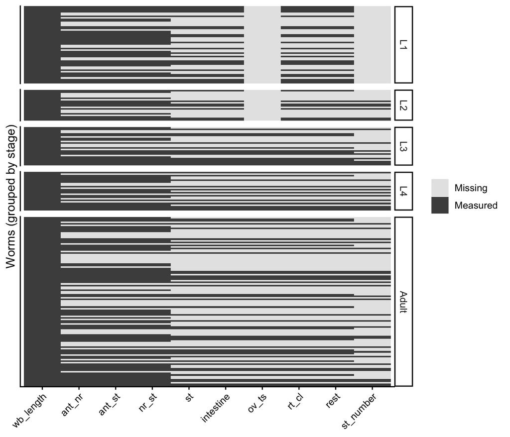

```r
miss <- worms |>
  select(sample, stage, all_of(meas_cols)) |>
  arrange(stage, sample) |>
  mutate(sample = factor(sample, levels = sample)) |>
  pivot_longer(all_of(meas_cols), names_to = "measurement", values_to = "value") |>
  mutate(measurement = factor(measurement, levels = meas_cols),
         measured    = !is.na(value))

ggplot(miss, aes(x = measurement, y = sample, fill = measured)) +
  geom_tile() +
  scale_fill_manual(values = c(`TRUE` = "grey30", `FALSE` = "grey90"),
                    labels = c(`TRUE` = "Measured", `FALSE` = "Missing")) +
  facet_grid(stage ~ ., scales = "free_y", space = "free_y") +
  labs(x = NULL, y = "Worms (grouped by stage)", fill = NULL) +
  theme(axis.text.y  = element_blank(),
        axis.ticks.y = element_blank(),
        axis.text.x  = element_text(angle = 45, hjust = 1))
```

**Check your figure: click to see what it should look like**

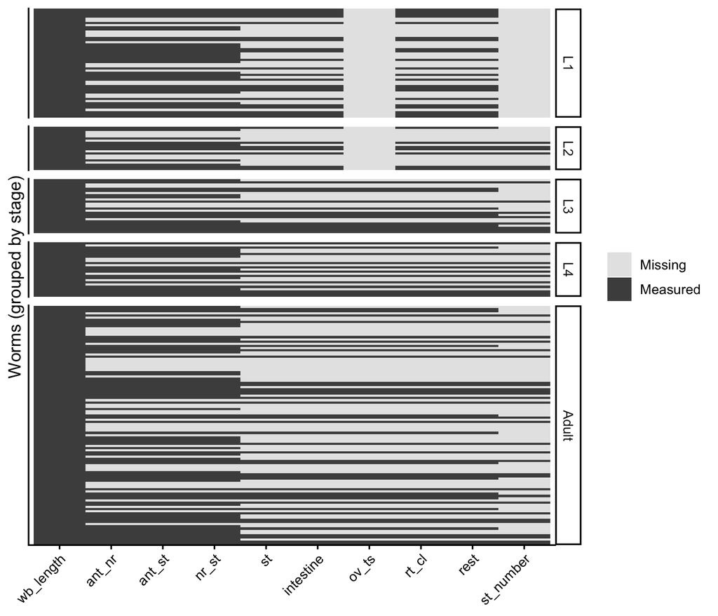

Expected result. The same image is in the project folder as `expected_figures/fig-missing.png`.

Reading the plot:

- `wb_length` is complete for everyone.
- Some worms have only the head landmarks (`ant_nr`, `nr_st`, `ant_st`), others only length, and others the full set.
- `ov_ts` is missing for all L1 (including newly hatched) and L2 worms. That is structural (the organ isn’t there yet), not a gap.

Rule for the rest of the tutorial

Every analysis uses **all the worms that have the measurements it needs**, and states how many that is. Don’t throw away a worm because it lacks an unrelated measurement.

## 5. Quality control

Do these checks **before** any plots or statistics.

### 5.1 Is `sample` a unique ID?

```r
worms |>
  summarise(n_rows = n(), n_ids = n_distinct(sample), all_unique = n_ids == n_rows)
```

| n_rows | n_ids | all_unique |
| --- | --- | --- |
| 230 | 230 | TRUE |

`all_unique` should be `TRUE` (230 rows and 230 IDs), confirming that each row is a different worm. If it is `FALSE`, the same ID appears on more than one row. Find out why before going further.

### 5.2 Do the distances add up?

`ant_st` (anterior end to St entrance) should equal `ant_nr` plus `nr_st`. Differences beyond rounding suggest a typing or measurement error.

What this analysis does, and why it matters

**What it does.** For every worm with all three head measurements, it works out how far `ant_st` is from `ant_nr + nr_st`, as a percentage of body length. Any worm more than 1% out is listed.

**Why it matters.** Statistics can’t tell a real measurement from a typo. A single mistyped value (an extra digit, or two numbers swapped) can shift a group mean, make a slope look steeper, or create a “significant” difference that isn’t there. Errors like this are cheap to catch now and expensive to discover after publication. Checks that use the data’s own internal logic (parts that should add up, values that should be positive, IDs that should be unique) are the most reliable way to find them.

```r
worms <- worms |>
  mutate(err_ant_st_pct = (ant_st - (ant_nr + nr_st)) / wb_length * 100)

qc_flagged <- worms |>
  filter(abs(err_ant_st_pct) > 1) |>        # more than 1% of body length out
  select(sample, lifestage, wb_length, ant_nr, nr_st, ant_st, err_ant_st_pct)

qc_flagged
```

| sample | lifestage | wb_length | ant_nr | nr_st | ant_st | err_ant_st_pct |
| --- | --- | --- | --- | --- | --- | --- |
| S009 | L1 (newly hatched) | 231.2 | 20.7 | 15.3 | 57.44 | 9.273356 |
| S078 | L3 | 1564.2 | 131.6 | 126.9 | 413.60 | 9.915612 |

**Check your output: click to see what it should look like**

```
# A tibble: 2 × 7
  sample lifestage          wb_length ant_nr nr_st ant_st err_ant_st_pct
  <chr>  <fct>                  <dbl>  <dbl> <dbl>  <dbl>          <dbl>
1 S009   L1 (newly hatched)      231.   20.7  15.3   57.4           9.27
2 S078   L3                     1564.  132.  127.   414.            9.92
```

The two planted errors show up (samples S009 and S078 in the provided data). Never silently delete a suspicious worm. The best fix is to go back to the original measurement. If you can’t, **flag the value and set it to `NA`**, keeping the worm’s other measurements:

```r
worms <- worms |>
  mutate(
    ant_st_flag = coalesce(abs(err_ant_st_pct) > 1, FALSE),
    ant_st      = if_else(ant_st_flag, NA_real_, ant_st),
    ant_st_pct  = if_else(ant_st_flag, NA_real_, ant_st_pct)
  )
```

### 5.3 Do the regions make up the whole body?

Among fully measured worms, the percentage columns (calculated in R from the lengths) should sum to about 100. If they do, the regions you recorded add up to the whole-body length.

```r
worms |>
  filter(!is.na(st_pct)) |>                          # fully measured worms
  mutate(pct_sum = rowSums(pick(all_of(pct_cols)), na.rm = TRUE)) |>
  summarise(min = min(pct_sum), max = max(pct_sum))
```

| min | max |
| --- | --- |
| 99.90575 | 100.0434 |

Here they sum to ~100, so the regions partition the body. **If your real data does not, the regions overlap** (or a region is missing), and you should not analyse the percentages as parts of a whole.

Because the percentages are calculated from the lengths (Section 3.5), they can never disagree with them. This check is really testing the **lengths themselves**: do the regions you recorded add up to `wb_length`? That is why it is worth keeping.

## 6. Growth: body length over time

How the analysis is organised

**Sections 6 to 11 focus on the worms**: growth, body plan, scaling, sex differences, PCA and stichosome number. They treat every worm as an independent observation, which is the simplest way to see the patterns.

**Sections 12 and 13 then bring in the mice.** Worms from the same mouse tend to resemble each other, so they are not fully independent. Section 12 shows this in the data, and Section 13 uses mixed-effects models to revisit the sex, growth and scaling comparisons while accounting for mouse. You will see which conclusions hold, and how much less certain some of them become. **Section 14** then fits a growth curve through all the timepoints, with mouse included.

Every worm has `wb_length`, so this plot uses all of them.

```r
worms |>
  group_by(dpi, lifestage) |>
  summarise(n_worms = n(),
            n_mice  = n_distinct(host_id, na.rm = TRUE),
            mean_um = mean(wb_length),
            sd_um   = sd(wb_length),
            .groups = "drop")
```

| dpi | lifestage | n_worms | n_mice | mean_um | sd_um |
| --- | --- | --- | --- | --- | --- |
| 0 | L1 (newly hatched) | 30 | 0 | 225.79 | 22.37981 |
| 3 | L1 | 20 | 4 | 278.55 | 34.25635 |
| 9 | L2 | 20 | 4 | 694.25 | 43.71038 |
| 14 | L3 | 25 | 5 | 1561.50 | 163.82951 |
| 21 | L4 | 25 | 5 | 4407.74 | 374.92033 |
| 35 | Adult female | 30 | 5 | 24846.93 | 2638.95279 |
| 35 | Adult male | 30 | 5 | 19418.95 | 1816.09702 |
| 42 | Adult female | 25 | 5 | 28834.37 | 3361.98717 |
| 42 | Adult male | 25 | 5 | 22567.31 | 1813.13370 |

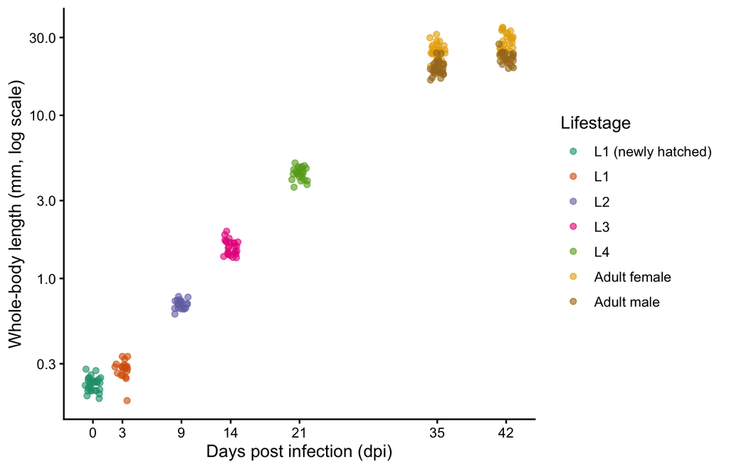

```r
dpi_breaks <- worms |> distinct(dpi) |> pull(dpi)     # one axis tick per sampling day

p_growth <- ggplot(worms, aes(x = dpi, y = wb_length / 1000, colour = lifestage)) +
  # jitter x only (never jitter measurements); a fixed seed gives everyone the same picture
  geom_point(alpha = 0.6, position = position_jitter(width = 0.8, height = 0, seed = 1)) +
  scale_y_log10() +
  scale_x_continuous(breaks = dpi_breaks) +
  scale_colour_brewer(palette = "Dark2") +
  labs(x = "Days post infection (dpi)",
       y = "Whole-body length (mm, log scale)",
       colour = "Lifestage")

p_growth
```

**Check your figure: click to see what it should look like**

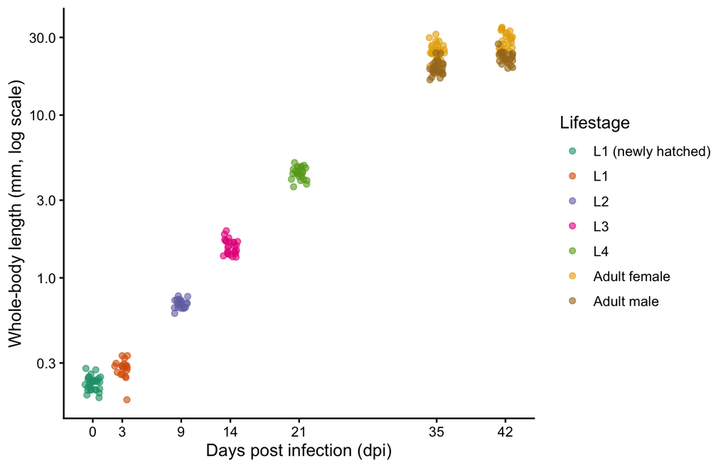

Expected result. The same image is in the project folder as `expected_figures/fig-growth.png`.

A **log scale** is used because worms grow by orders of magnitude. On a linear axis the larvae would be squashed against the bottom. On the log scale, equal vertical distances mean equal fold-changes.

How to read this

- Each dot is one worm, coloured by lifestage. Dots are spread a little sideways (jittered) so they don’t hide each other. Their **height is never changed**.
- Worms grow about **130-fold**, from about 0.23 mm at hatching to about 29 mm in adult females at 42 dpi.
- Each larval step (L1 to L2, L2 to L3, L3 to L4) multiplies length by about 2.2 to 2.8 times. The biggest jump is from L4 (21 dpi) to adult (35 dpi), about 5.6-fold in females, over a longer gap of 14 days.
- At 35 and 42 dpi, adult females (yellow) sit above males (brown): females are longer. Section 9 looks at this properly.

## 7. Body plan: how proportions change across lifestages

Which fraction of the body is stichosome, intestine and so on at each stage? A stacked bar of the mean percentages answers this. It uses fully measured worms only, and we show how many that is.

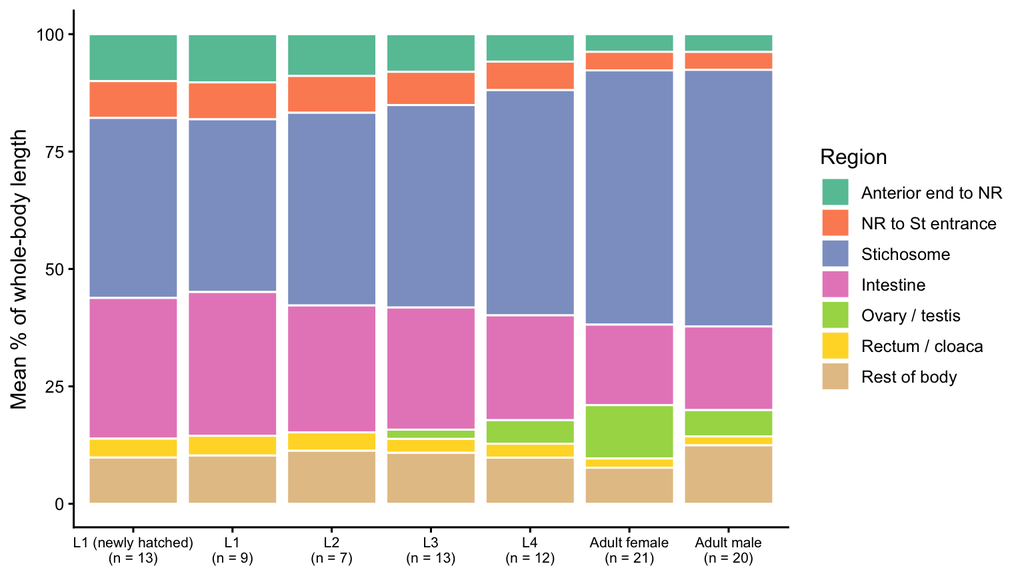

```r
comp <- worms |>
  filter(!is.na(st_pct)) |>                              # fully measured worms
  select(sample, lifestage, all_of(pct_cols)) |>
  pivot_longer(all_of(pct_cols), names_to = "segment", values_to = "pct") |>
  drop_na(pct) |>                                        # drops ov/ts in L1, L2
  mutate(segment = str_remove(segment, "_pct$"),
         segment = factor(segment, levels = names(segment_labels),
                          labels = segment_labels))

n_full <- worms |> filter(!is.na(st_pct)) |> count(lifestage)

comp_mean <- comp |>
  group_by(lifestage, segment) |>
  summarise(mean_pct = mean(pct), .groups = "drop") |>
  left_join(n_full, by = "lifestage") |>
  mutate(label = paste0(lifestage, "\n(n = ", n, ")"),
         label = fct_reorder(label, as.numeric(lifestage)))

p_comp <- ggplot(comp_mean, aes(x = label, y = mean_pct, fill = segment)) +
  geom_col(colour = "white") +
  scale_fill_brewer(palette = "Set2") +
  labs(x = NULL, y = "Mean % of whole-body length", fill = "Region") +
  theme(axis.text.x = element_text(size = 8))

p_comp
```

**Check your figure: click to see what it should look like**

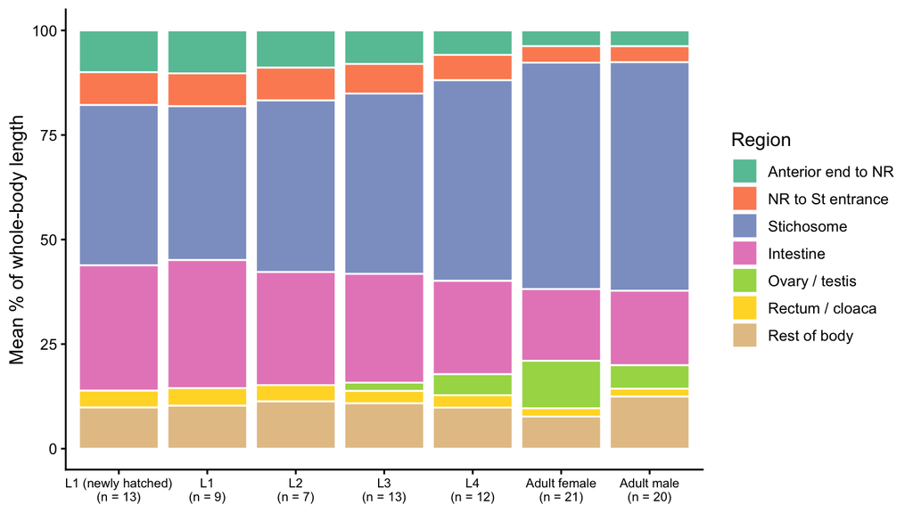

Expected result. The same image is in the project folder as `expected_figures/fig-composition.png`.

In the L1 and L2 groups the ovary/testis can’t be measured, so that space is absorbed into “Rest of body”. Interpret the early bars with that in mind. This figure is descriptive: any formal comparison of proportions between groups should also account for mouse (Section 13).

How to read this

- Each bar is one group, and each coloured block is the **mean share** of body length taken by one region. The n under each bar is the number of fully measured worms behind it.
- The **stichosome’s share rises** from about 38% in newly hatched L1 to about 54% in adults, while the **intestine’s falls** from about 30% to about 17%. By adulthood the stichosome takes up more than half the body.
- The ovary/testis appears in L3 (about 2%). It reaches about 11% in adult females but only about 6% in males. Males make up the difference with a longer “rest of body” (about 12%, against 8% in females).
- These are means, so they hide the variation between worms. Exercise 3 models one of these percentages formally.

### 7.1 Relative versus absolute length

Every bar above reaches 100%, so the plot shows the **shape** of the body plan but hides how **big** each worm is. Stacking the mean region lengths in mm (the same fully measured worms) shows the other half of the story. Adults are about 100 times longer than newly hatched L1 larvae, so on one shared axis the larvae would be invisible. We therefore give larvae and adults their own panel and axis.

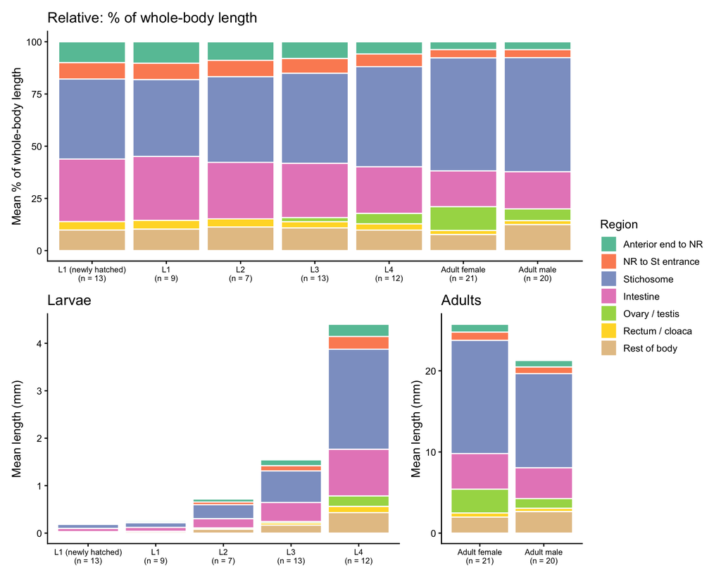

```r
comp_abs <- worms |>
  filter(!is.na(st_pct)) |>                              # the same fully measured worms
  select(sample, lifestage, stage, all_of(names(segment_labels))) |>
  pivot_longer(all_of(names(segment_labels)), names_to = "segment", values_to = "length_um") |>
  drop_na(length_um) |>                                  # drops ov/ts in L1, L2
  mutate(segment = factor(segment, levels = names(segment_labels),
                          labels = segment_labels)) |>
  group_by(stage, lifestage, segment) |>
  summarise(mean_mm = mean(length_um) / 1000, .groups = "drop") |>
  left_join(n_full, by = "lifestage") |>
  mutate(label = paste0(lifestage, "\n(n = ", n, ")"),
         label = fct_reorder(label, as.numeric(lifestage)))

abs_bars <- function(d, title) {
  ggplot(d, aes(x = label, y = mean_mm, fill = segment)) +
    geom_col(colour = "white") +
    scale_fill_brewer(palette = "Set2", drop = FALSE) +   # same colours in both panels
    labs(x = NULL, y = "Mean length (mm)", fill = "Region", title = title) +
    theme(axis.text.x = element_text(size = 8))
}

p_abs <- abs_bars(filter(comp_abs, stage != "Adult"), "Larvae") +
  abs_bars(filter(comp_abs, stage == "Adult"), "Adults") +
  plot_layout(widths = c(5, 2))

# relative (top) above absolute (bottom), sharing one legend
(p_comp + labs(title = "Relative: % of whole-body length")) / p_abs +
  plot_layout(guides = "collect")
```

**Check your figure: click to see what it should look like**

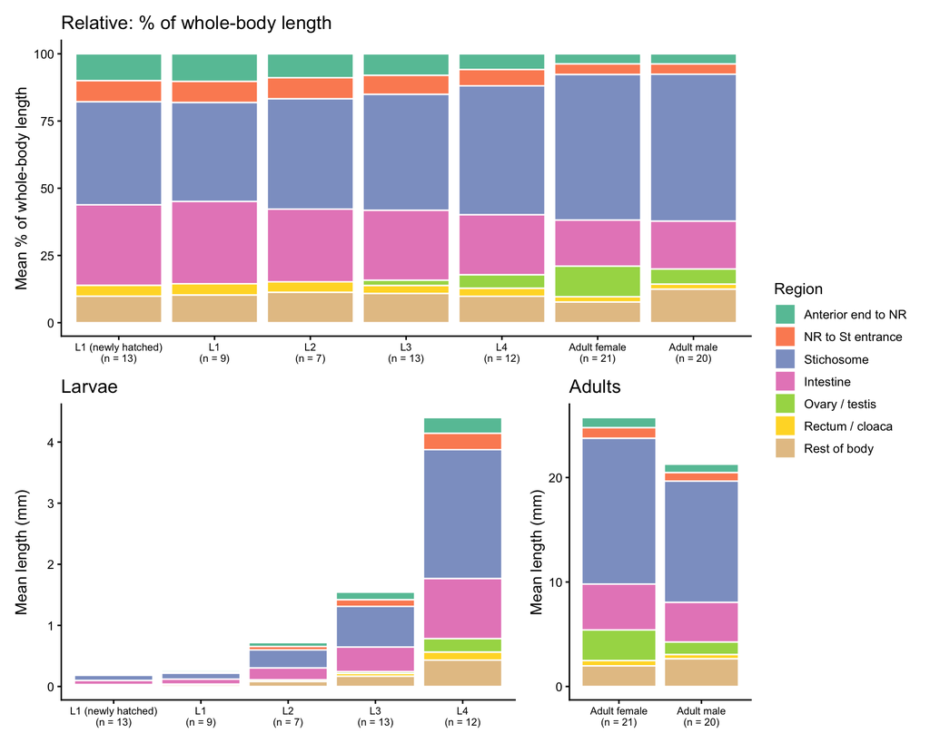

Expected result. The same image is in the project folder as `expected_figures/fig-composition-abs.png`.

Read the two rows together:

- **Relative (top)**: the stichosome’s *share* rises from about 38% to over 50%. The worm is changing shape.
- **Absolute (bottom)**: every region gets longer, by very different amounts. The stichosome grows from under 0.1 mm in a newly hatched L1 to over 10 mm in an adult female. The total height of each bar is the mean body length of these worms.
- A region can lose share while still growing in absolute length. The intestine does exactly that (compare its slope below 1 in Section 8).

Don’t fix the size problem with a log axis. On a log scale each stacked segment’s height no longer matches its length, so the stack becomes misleading. Use separate panels, as here, or plot each region on its own (Section 8).

### 7.2 Percentages are parts of a whole

The percentages in Section 7 always add up to 100. That sounds harmless, but it means they are **not free to vary independently**: if one region’s share goes up, the others *must* go down, whatever the biology. Data like these are called **compositional data**, and they need some care once you go beyond describing them.

What this analysis does, and why it matters

**The problem.** Percentages have three quirks:

1. **They manufacture negative correlations.** Because the shares add to 100, they tend to be negatively correlated even when the regions themselves are completely unrelated. A negative correlation between two percentages can look like a biological trade-off (“worms with a bigger stichosome have a smaller intestine”) when it is just arithmetic.
2. **They depend on what else is in the whole.** The stichosome’s share changes if you add or remove another region from the total, even though the stichosome itself hasn’t changed. In L1 and L2 the ovary/testis can’t be measured and its space is absorbed into “rest of body” (Section 7), so the percentages of the early stages aren’t strictly comparable with the later ones.
3. **They are squeezed between 0 and 100**, so their spread depends on their mean, which linear models don’t expect.

**Why it matters.** Body proportions are central to morphometrics, and percentages are the obvious way to express them. Used for description, as in the bars of Section 7, they are fine. Correlated or modelled, they can produce patterns that aren’t there and hide ones that are. Compositional data analysis is standard in geology and microbiome studies, and less well known in morphometrics.

**First, a demonstration with made-up numbers.** Three body regions whose lengths are drawn completely independently, so they have no relationship at all:

```r
set.seed(1)
toy <- tibble(a = rlnorm(1000, log(10), 0.2),   # three independent lengths, each about 10
              b = rlnorm(1000, log(10), 0.2),
              c = rlnorm(1000, log(10), 0.2))

toy_pct <- toy / rowSums(toy) * 100               # each region as % of the total

round(cor(toy), 2)       # correlations between the lengths
```

```
##      a    b    c
## a 1.00 0.01 0.05
## b 0.01 1.00 0.02
## c 0.05 0.02 1.00
```

```r
round(cor(toy_pct), 2)   # correlations between the percentages
```

```
##       a     b     c
## a  1.00 -0.52 -0.48
## b -0.52  1.00 -0.50
## c -0.48 -0.50  1.00
```

**Check your output: click to see what it should look like**

```
      a    b    c
a 1.00 0.01 0.05
b 0.01 1.00 0.02
c 0.05 0.02 1.00
      a     b     c
a  1.00 -0.52 -0.48
b -0.52  1.00 -0.50
c -0.48 -0.50  1.00
```

The lengths are uncorrelated (all about 0), as they should be. The percentages all correlate at about **−0.5**, purely because they must add to 100. With more regions the effect is weaker, but when one region dominates, as the stichosome does in adults, it is strong.

**Now the real data.** In adult females, how do the stichosome and intestine vary together?

```r
worms |>
  filter(lifestage == "Adult female", !is.na(st_pct), !is.na(intestine_pct)) |>
  summarise(n_worms          = n(),
            cor_percentages  = cor(st_pct, intestine_pct),
            cor_lengths      = cor(log(st), log(intestine)))
```

| n_worms | cor_percentages | cor_lengths |
| --- | --- | --- |
| 21 | -0.7449178 | 0.4257046 |

**Check your output: click to see what it should look like**

```
# A tibble: 1 × 3
  n_worms cor_percentages cor_lengths
    <int>           <dbl>       <dbl>
1      21          -0.745       0.426
```

The two correlations point in **opposite directions**. The lengths correlate positively (0.43): a bigger female tends to have both a longer stichosome and a longer intestine, simply because she is bigger. The percentages correlate negatively (−0.75), which would suggest a trade-off between the two organs. Most of that is the arithmetic from the demonstration: the stichosome takes up more than half the body, so a worm whose stichosome is a little longer than usual has every other share squeezed. A negative correlation between percentages is not, on its own, evidence of a trade-off.

**Comparing groups: percentages against log-ratios.** Do adult males and females differ in their body proportions? We test each region twice: once as a percentage, and once as a centred log-ratio. To keep the comparison fair, both use the same worms (adults with all seven regions measured), and both treat every worm as independent, as in Sections 6 to 11.

```r
regions <- names(segment_labels)   # all seven regions, ov_ts included (adults have one)

adult_comp <- worms |>
  filter(stage == "Adult") |>
  drop_na(all_of(regions)) |>
  pivot_longer(all_of(regions), names_to = "region", values_to = "length_um") |>
  group_by(sample) |>                                         # within each worm:
  mutate(pct = 100 * length_um / sum(length_um),             #   % of the seven regions (adds to 100)
         clr = log(length_um) - mean(log(length_um))) |>     #   centred log-ratio
  ungroup() |>
  mutate(region = factor(region, levels = regions, labels = segment_labels))

sex_test <- function(d, response) {
  lm(reformulate("sex", response), data = d) |>   # e.g. pct ~ sex
    broom::tidy() |>
    filter(term == "sexMale") |>
    select(estimate, p.value)
}

adult_comp |>
  group_by(region) |>
  group_modify(\(d, key) bind_cols(
    sex_test(d, "pct") |> rename(pct_diff = estimate, pct_p = p.value),
    sex_test(d, "clr") |> rename(clr_diff = estimate, clr_p = p.value))) |>
  ungroup() |>
  mutate(pct_diff       = round(pct_diff, 2),
         male_vs_female = round(exp(clr_diff), 2),            # CLR difference as a ratio
         across(c(pct_p, clr_p), \(p) if_else(p < 0.001, "<0.001", sprintf("%.2g", p)))) |>
  select(region, pct_diff, pct_p, male_vs_female, clr_p)
```

| region | pct_diff | pct_p | male_vs_female | clr_p |
| --- | --- | --- | --- | --- |
| Anterior end to NR | 0.02 | 0.89 | 1.04 | 0.12 |
| NR to St entrance | -0.12 | 0.24 | 1.00 | 0.92 |
| Stichosome | 0.50 | 0.62 | 1.04 | 0.21 |
| Intestine | 0.67 | 0.19 | 1.08 | 0.0044 |
| Ovary / testis | -5.76 | <0.001 | 0.51 | <0.001 |
| Rectum / cloaca | -0.07 | 0.21 | 1.00 | 0.84 |
| Rest of body | 4.77 | <0.001 | 1.68 | <0.001 |

**Check your output: click to see what it should look like**

```
# A tibble: 7 × 5
  region             pct_diff pct_p  male_vs_female clr_p
  <fct>                 <dbl> <chr>           <dbl> <chr>
1 Anterior end to NR     0.02 0.89             1.04 0.12
2 NR to St entrance     -0.12 0.24             1    0.92
3 Stichosome             0.5  0.62             1.04 0.21
4 Intestine              0.67 0.19             1.08 0.0044
5 Ovary / testis        -5.76 <0.001           0.51 <0.001
6 Rectum / cloaca       -0.07 0.21             1    0.84
7 Rest of body           4.77 <0.001           1.68 <0.001
```

How to read this

- `pct_diff` is how many **percentage points** larger the region’s share is in males than in females. `male_vs_female` is the CLR difference as a **ratio**: how much longer the region is in males, relative to the worm’s average region. 1.08 means 8% longer.
- **Both methods agree on the big differences.** Males have a much smaller testis than females have ovary (5.8 points less; a ratio of 0.51, about half), and a much longer rest of body (4.8 points more; a ratio of 1.68).
- **They disagree on the intestine.** As a percentage, the male intestine is 0.67 points larger, with p = 0.19: no evidence of a difference. As a log-ratio it is 8% longer, with p = 0.004. The simulation did build in a small real difference (males 19% of the body, females 18%, Appendix C), and the log-ratio picks it up while the percentage misses it.
- **But log-ratios need care too.** A CLR compares each region with the worm’s *average* region. When the ovary/testis halves and the rest of body grows by two thirds, that average shifts, and every other region’s CLR moves by about 3%. That is why the stichosome shows 1.04 even though the simulation gave it exactly the same share in both sexes. Part of the intestine’s 8% is this shift. When your question is about one specific pair of regions, use a simple log-ratio such as `log(intestine / st)` (Exercise 8).

**In practice:** use percentages to **describe** a body plan (Section 7’s bars), and log-ratios to **correlate, model or test** proportions. Always say what each ratio is relative to.

## 8. Scaling: do regions grow in proportion to the whole worm?

If a region grows at the same rate as the whole body, its share stays constant. If it grows faster or slower, its share changes. This is **allometry**. On log-log axes, the slope of a region’s length against whole-body length tells you which:

- **Slope = 1**: isometric (the region keeps its proportion)
- **Slope > 1**: the region gets proportionally larger as worms grow
- **Slope < 1**: the region gets proportionally smaller

This uses every worm that has the region measured (not just the fully measured ones).

What this analysis does, and why it matters

**What it does.** For each region, it fits a **linear regression**: the straight line that best predicts region length from body length. “Best” means the line that makes the vertical distances between the points and the line as small as possible (least squares). The **slope** of the line says how much region length changes for each unit change in body length.

**Why use logs of both lengths?** Growth is multiplicative: a region that is always 40% of the body doubles when the body doubles. Biologists describe this with a **power law**, region = a × body^b. Taking logs of both sides turns it into a straight line, log(region) = log(a) + b × log(body), so the **slope of the log-log line is the exponent b**. A slope of 1 means the region keeps its proportion; above 1, it gets relatively bigger as the worm grows.

**Why it matters.** Percentages (Section 7) show *that* proportions change, but not *how fast* each region grows relative to the body. A slope with a confidence interval puts a number on it, and lets you test it against 1. Allometric slopes are the standard way to compare growth patterns between regions, stages, sexes or species, because they don’t depend on the size of the animals you happened to measure.

**Confidence intervals.** A **95% confidence interval** is the range of values that are reasonably compatible with the data. If you repeated the whole study many times, about 95% of the intervals calculated this way would contain the true value. A narrow interval means the estimate is precise. If the interval excludes a value of interest (here, 1), the data give good evidence against that value.

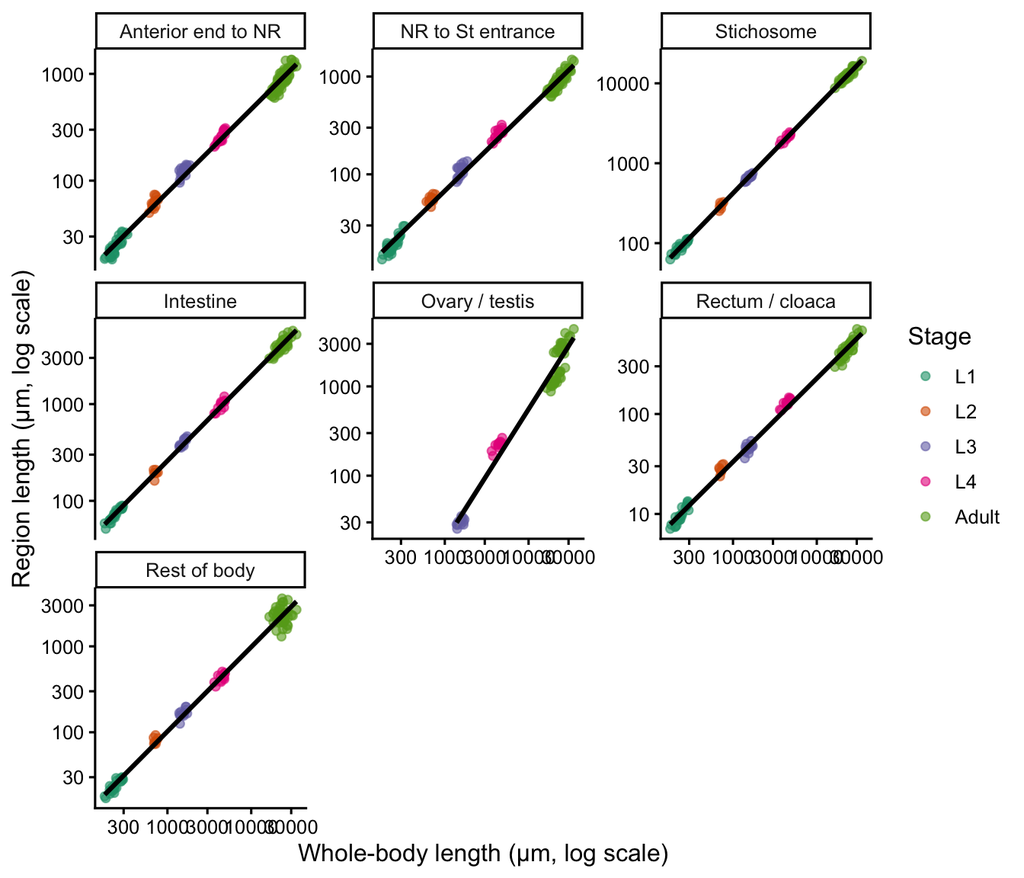

```r
seg_cols <- names(segment_labels)

seg_long <- worms |>
  select(sample, any_of("host_id"), stage, wb_length, all_of(seg_cols)) |>
  pivot_longer(all_of(seg_cols), names_to = "segment", values_to = "length_um") |>
  drop_na(length_um) |>
  filter(length_um > 0) |>                                   # logs need positive values
  mutate(segment = factor(segment, levels = names(segment_labels),
                          labels = segment_labels))

p_scaling <- ggplot(seg_long, aes(x = wb_length, y = length_um)) +
  geom_point(aes(colour = stage), alpha = 0.6) +
  geom_smooth(method = "lm", colour = "black") +
  scale_x_log10() +
  scale_y_log10() +
  scale_colour_brewer(palette = "Dark2") +
  facet_wrap(~ segment, scales = "free_y") +
  labs(x = "Whole-body length (µm, log scale)",
       y = "Region length (µm, log scale)", colour = "Stage")

p_scaling
```

**Check your figure: click to see what it should look like**

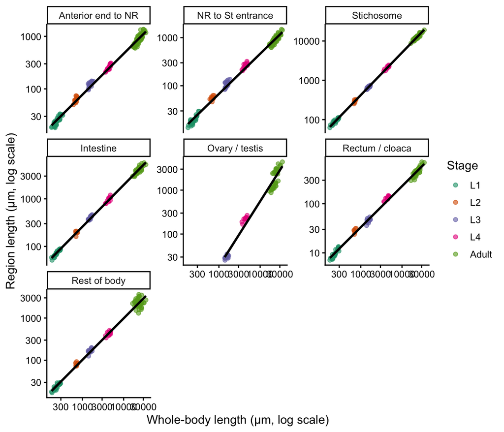

Expected result. The same image is in the project folder as `expected_figures/fig-scaling.png`.

Extract the slope for each region, with a confidence interval.

Advanced code: you don’t need to follow every detail

This chunk fits **one straight-line model per region** and collects the slopes into one table. What each line does:

1. `group_by(segment)` splits the long table into one group per region.
2. `group_modify(\(d, key) ...)` runs the same job on each group. Inside it, `d` is that region’s rows.
3. `lm(log10(length_um) ~ log10(wb_length), data = d)` fits the line: region length against body length, both on log scales. Read `~` as “is modelled by”.
4. `broom::tidy(..., conf.int = TRUE)` turns the model’s results into a small table, with confidence intervals.
5. `filter(term == "log10(wb_length)")` keeps the slope row and drops the intercept row.

If you want to see one model on its own first, try `lm(log10(length_um) ~ log10(wb_length), data = filter(seg_long, segment == "Stichosome"))` in the Console.

```r
slopes <- seg_long |>
  group_by(segment) |>
  group_modify(\(d, key) broom::tidy(lm(log10(length_um) ~ log10(wb_length),
                                        data = d),
                                     conf.int = TRUE)) |>
  filter(term == "log10(wb_length)")

slopes |> select(segment, slope = estimate, conf.low, conf.high)
```

| segment | slope | conf.low | conf.high |
| --- | --- | --- | --- |
| Anterior end to NR | 0.7796884 | 0.7699741 | 0.7894026 |
| NR to St entrance | 0.8340091 | 0.8238265 | 0.8441917 |
| Stichosome | 1.0801830 | 1.0738224 | 1.0865435 |
| Intestine | 0.8772606 | 0.8685719 | 0.8859493 |
| Ovary / testis | 1.4806858 | 1.4149411 | 1.5464305 |
| Rectum / cloaca | 0.8344632 | 0.8224204 | 0.8465060 |
| Rest of body | 0.9823694 | 0.9611611 | 1.0035777 |

**Check your output: click to see what it should look like**

```
# A tibble: 7 × 4
# Groups:   segment [7]
  segment            slope conf.low conf.high
  <fct>              <dbl>    <dbl>     <dbl>
1 Anterior end to NR 0.780    0.770     0.789
2 NR to St entrance  0.834    0.824     0.844
3 Stichosome         1.08     1.07      1.09
4 Intestine          0.877    0.869     0.886
5 Ovary / testis     1.48     1.41      1.55
6 Rectum / cloaca    0.834    0.822     0.847
7 Rest of body       0.982    0.961     1.00
```

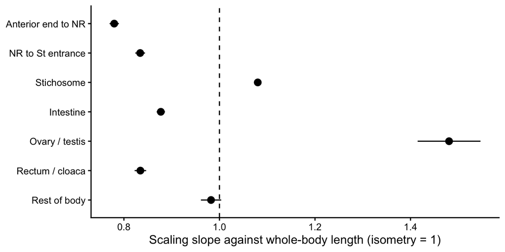

```r
ggplot(slopes, aes(x = estimate, y = fct_rev(segment))) +
  geom_vline(xintercept = 1, linetype = "dashed") +
  geom_pointrange(aes(xmin = conf.low, xmax = conf.high)) +
  labs(x = "Scaling slope against whole-body length (isometry = 1)", y = NULL)
```

**Check your figure: click to see what it should look like**

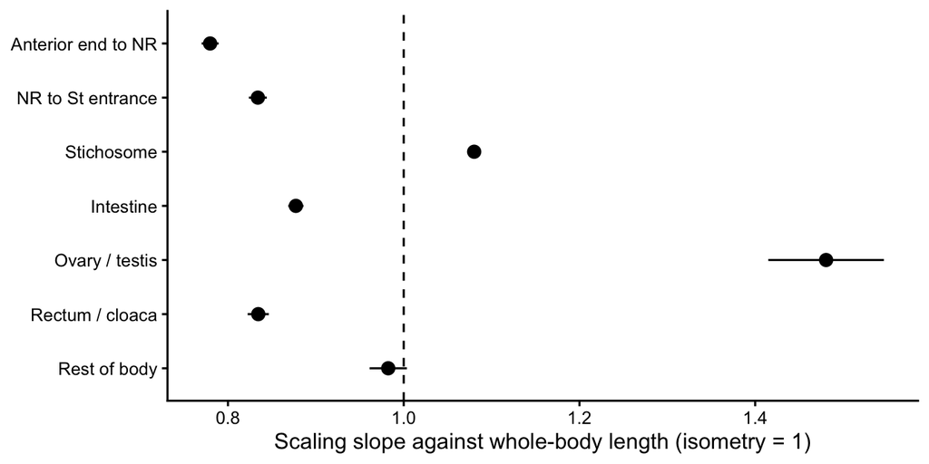

Expected result. The same image is in the project folder as `expected_figures/fig-slopes.png`.

Regions that gain share over development (here the stichosome) have a slope above 1, and regions that lose share (here the intestine) have a slope below 1.

How to read this

- Each point is one region’s slope. The horizontal line through it is the **95% confidence interval**: the range of slopes that fit the data well. The dashed line at 1 is isometry.
- If an interval does **not** cross the dashed line, that region clearly does not scale isometrically. Only “rest of body” (0.98, interval 0.96 to 1.00) is close to isometric.
- The steepest slope is the **ovary/testis (about 1.5)**: gonads barely exist in larvae and grow fast late in development. The **stichosome (1.08)** grows a little faster than the body, so it gains share.
- The head regions (anterior end to NR 0.78, NR to St 0.83), the intestine (0.88) and the rectum/cloaca (0.83) grow more slowly than the body, so they lose share. That is the same pattern as the stacked bars in Section 7, now with a number and an uncertainty attached.
- The intervals look very narrow because this analysis treats every worm as independent and pools all stages. See the cautions below.

Three cautions

1. **Parts of a whole are not independent.** The regions sum to the body length, so if one takes a bigger share, others must shrink. Don’t over-interpret one slope in isolation.
2. **These slopes pool all lifestages.** They mix within-stage growth with the step changes between stages. To ask “does the region scale within adults?”, repeat the model on one stage at a time.
3. **These confidence intervals ignore mouse.** Section 13.7 refits one slope with a mouse random effect.

## 9. Sex differences in adults: look at the data

Males and females can only be compared in the adult stages. We start by plotting the data with n, then model it in Section 13.

```r
adults <- worms |>
  filter(stage == "Adult") |>
  mutate(dpi_f = factor(dpi))

adults |>
  group_by(dpi, sex) |>
  summarise(n_worms = n(), n_mice = n_distinct(host_id), .groups = "drop")
```

| dpi | sex | n_worms | n_mice |
| --- | --- | --- | --- |
| 35 | Female | 30 | 5 |
| 35 | Male | 30 | 5 |
| 42 | Female | 25 | 5 |
| 42 | Male | 25 | 5 |

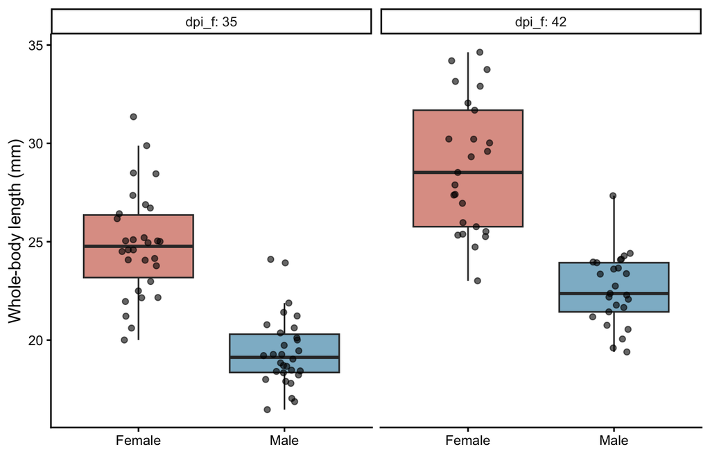

```r
sex_cols <- c(Female = "#C8553D", Male = "#2E86AB")

ggplot(adults, aes(x = sex, y = wb_length / 1000, fill = sex)) +
  geom_boxplot(outlier.shape = NA, alpha = 0.6) +
  geom_point(alpha = 0.6, position = position_jitter(width = 0.15, height = 0, seed = 1)) +
  facet_wrap(~ dpi_f, labeller = label_both) +
  scale_fill_manual(values = sex_cols) +
  labs(x = NULL, y = "Whole-body length (mm)") +
  theme(legend.position = "none")
```

**Check your figure: click to see what it should look like**

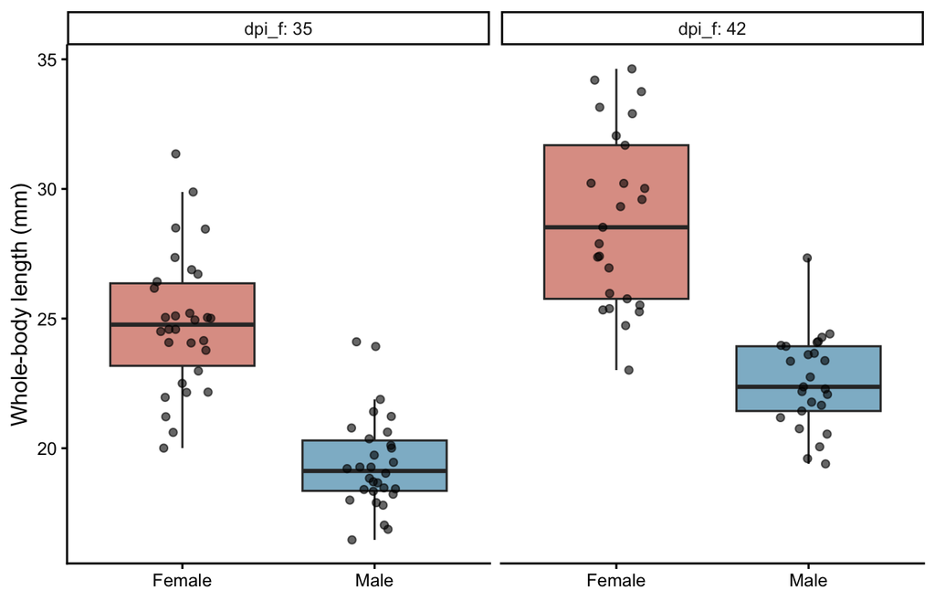

Expected result. The same image is in the project folder as `expected_figures/fig-sex.png`.

How to read this

- In a **boxplot**, the thick line is the **median** (the middle worm). The box holds the **middle 50%** of worms, and the whiskers reach the furthest worms that aren’t unusually far out. The dots are the individual worms; the boxplot’s own outlier points are switched off because every worm is already drawn.
- Females are longer at both timepoints: median about **24.8 mm against 19.1 mm** at 35 dpi, and **28.5 mm against 22.4 mm** at 42 dpi. Both sexes are longer at 42 dpi than at 35 dpi.
- The boxes for the two sexes hardly overlap, which suggests a clear difference. But this plot treats every worm as independent. Section 13 tests it while allowing for mouse.

In this design, **both sexes come from each mouse**, so sex is compared *within* mice, while timepoint (35 vs 42 dpi) is compared *between* mice. This distinction matters when we model the sex difference while accounting for mouse in Section 13.

## 10. Multivariate analysis: PCA across lifestages

PCA summarises several region lengths at once, so we can see overall development and which regions drive it. **PCA needs complete rows**, so choose your variables with the missingness map in mind.

What this analysis does, and why it matters

**What it does.** Each worm has six region lengths, so it is a point in a six-dimensional space, which you can’t draw. **Principal component analysis (PCA)** finds new axes through that cloud of points. The first, **PC1**, points in the direction along which the worms differ most. **PC2** is the direction of the next-largest difference, at right angles to PC1, and so on. Each PC is a weighted combination of the original measurements; the weights are called **loadings**. Plotting PC1 against PC2 is like turning the cloud until you find the most informative view of it.

**Why log and scale the data?** Logs make PCA about **proportional** differences, as in Section 8. **Scaling** (`scale. = TRUE`) gives every region the same weight. Without it, long regions such as the stichosome would dominate simply because their numbers are bigger.

**Why it matters.** Six measurements that are all strongly related carry much less than six separate pieces of information. PCA shows how many independent patterns there really are, which groups separate, and which measurements drive the separation, without running a separate test for every measurement. It is **descriptive**: it shows patterns but does not test them. To test whether groups differ on a PC, use the scores in a model (Exercise 4).

Choices made here:

- Use the **region lengths** (not the `*_pct` columns, which carry the same information as the lengths, and not `wb_length` or `ant_st`, which are sums of the others).
- **Leave out `ov_ts`**, because it is structurally missing in L1 and L2. Including it would remove whole lifestages from the analysis.
- Use **log-transformed** lengths and scale them.

```r
pca_vars <- c("ant_nr", "nr_st", "st", "intestine", "rt_cl", "rest")

pca_data <- worms |>
  select(sample, any_of("host_id"), dpi, lifestage, stage, all_of(pca_vars)) |>
  drop_na(all_of(pca_vars))      # only the variables in the PCA: host_id may legitimately be NA

nrow(pca_data)                 # how many worms contribute?
```

```
## [1] 95
```

```r
count(pca_data, lifestage)     # ... and from which stages?
```

| lifestage | n |
| --- | --- |
| L1 (newly hatched) | 13 |
| L1 | 9 |
| L2 | 7 |
| L3 | 13 |
| L4 | 12 |
| Adult female | 21 |
| Adult male | 20 |

**Check your output: click to see what it should look like**

```
[1] 95
# A tibble: 7 × 2
  lifestage              n
  <fct>              <int>
1 L1 (newly hatched)    13
2 L1                     9
3 L2                     7
4 L3                    13
5 L4                    12
6 Adult female          21
7 Adult male            20
```

The PCA uses only the **fully measured subset**. Check that every lifestage is still represented in reasonable numbers, as above. If one stage vanished, conclusions about it would be impossible. Also avoid filling gaps with the mean: that shrinks variation and distorts the axes.

Note that `drop_na()` is restricted to the PCA variables. A bare `drop_na()` would also remove worms whose `host_id` is missing (the newly hatched larvae), which is not what we want here.

```r
pca <- pca_data |>
  select(all_of(pca_vars)) |>
  mutate(across(everything(), log10)) |>
  prcomp(scale. = TRUE)

summary(pca)
```

```
## Importance of components:
##                           PC1     PC2     PC3     PC4     PC5     PC6
## Standard deviation     2.4448 0.10061 0.06972 0.05582 0.05420 0.04441
## Proportion of Variance 0.9962 0.00169 0.00081 0.00052 0.00049 0.00033
## Cumulative Proportion  0.9962 0.99785 0.99866 0.99918 0.99967 1.00000
```

How to read this

- **Standard deviation** is how spread out the worms are along each principal component (PC). **Proportion of Variance** is the share of all the variation that PC captures, and **Cumulative Proportion** is the running total.
- **PC1 captures 99.6%**. Almost all the variation among these worms is **size**: a big worm has big everything. That is expected when lengths span a 100-fold range.
- PC2 captures only 0.17%. It describes small differences in proportions, which is the shape. Section 10.1 removes size to look at shape directly.

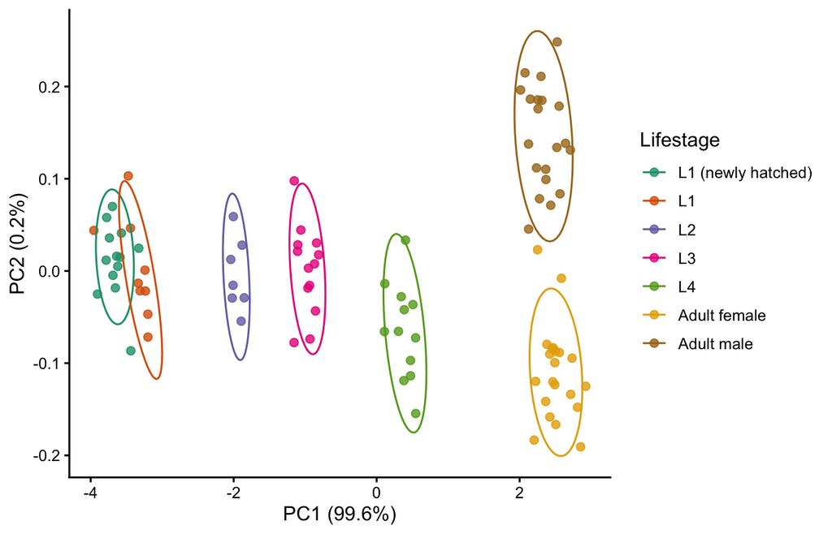

```r
# share of the variation captured by each PC, as a tibble (columns PC, std.dev, percent, cumulative)
var_explained <- broom::tidy(pca, matrix = "eigenvalues")

pc_lab <- function(i) {
  share <- var_explained |> filter(PC == i) |> pull(percent)
  str_glue("PC{i} ({round(100 * share, 1)}%)")
}

scores <- bind_cols(pca_data |> select(sample, any_of("host_id"), dpi, lifestage),
                    as_tibble(pca$x))

p_pca <- ggplot(scores, aes(x = PC1, y = PC2, colour = lifestage)) +
  geom_point(size = 2, alpha = 0.8) +
  stat_ellipse(level = 0.9) +
  scale_colour_brewer(palette = "Dark2") +
  labs(x = pc_lab(1), y = pc_lab(2), colour = "Lifestage")

p_pca
```

**Check your figure: click to see what it should look like**

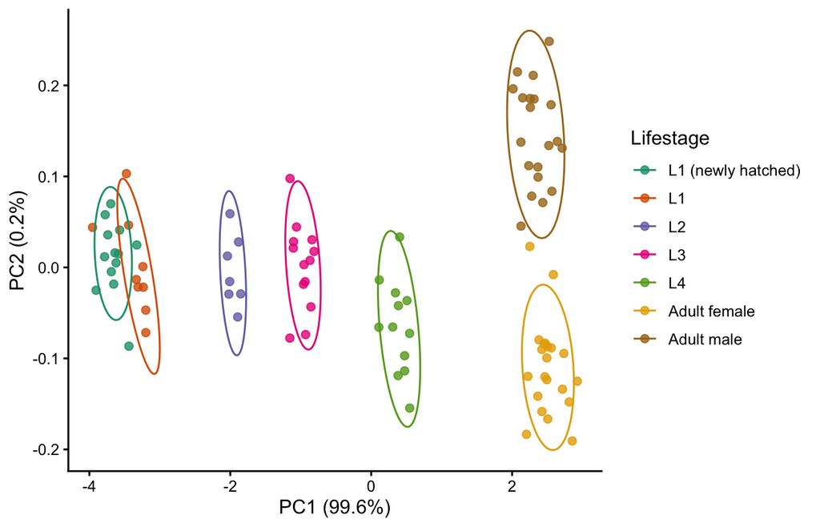

Expected result. The same image is in the project folder as `expected_figures/fig-pca.png`.

Expect PC1 to be mostly **overall size**, ordering worms from L1 through adults, because all regions grow together. PC2 and later axes describe how the proportions differ.

How to read this

- Each dot is one worm. Each ellipse encloses roughly 90% of a group, to show where most of its worms lie.
- **PC1** orders the worms by lifestage, from L1 (left) to adults (right): it is size. Newly hatched and 3 dpi L1 larvae overlap, because they are almost the same size.
- **PC2** separates adult males (above 0) from adult females (below). The loadings plot below shows why.
- The two axes are on very different scales: PC2 spans about 0.4 units and PC1 about 7. The plot stretches PC2 so you can see it.
- The direction of a PC is arbitrary: flipping its sign gives exactly the same analysis. If your plot is a **mirror image** of the expected one, that is fine.

```r
loadings <- as_tibble(pca$rotation, rownames = "region")
loadings
```

| region | PC1 | PC2 | PC3 | PC4 | PC5 | PC6 |
| --- | --- | --- | --- | --- | --- | --- |
| ant_nr | 0.4083402 | -0.23188677 | 0.5091836 | 0.69441588 | -0.06604798 | 0.18342060 |
| nr_st | 0.4083840 | -0.25073005 | 0.3552583 | -0.67978792 | -0.35779148 | 0.23242656 |
| st | 0.4083565 | -0.03981803 | -0.7399406 | 0.14574752 | -0.21532127 | 0.46534057 |
| intestine | 0.4086533 | -0.01259413 | -0.1735087 | 0.06564117 | -0.35454573 | -0.82019948 |
| rt_cl | 0.4083616 | -0.33863711 | -0.1088158 | -0.16078698 | 0.81432869 | -0.13319612 |
| rest | 0.4073931 | 0.87575327 | 0.1583204 | -0.06535604 | 0.18007163 | 0.07296944 |

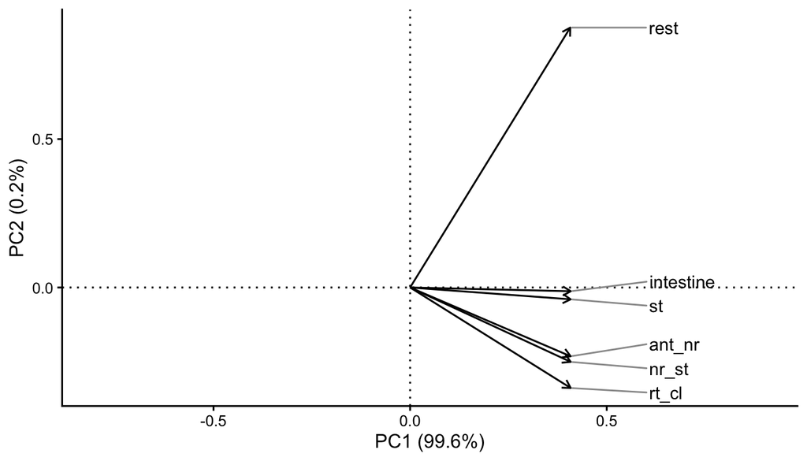

```r
ggplot(loadings, aes(x = PC1, y = PC2)) +
  geom_hline(yintercept = 0, linetype = "dotted") +
  geom_vline(xintercept = 0, linetype = "dotted") +
  geom_segment(aes(x = 0, y = 0, xend = PC1, yend = PC2),
               arrow = arrow(length = unit(0.2, "cm"))) +
  # labels stacked to the right of the arrow tips, joined to them by thin lines
  ggrepel::geom_text_repel(aes(x = PC1, y = PC2, label = region),
                           nudge_x = 0.2, direction = "y", hjust = 0,
                           min.segment.length = 0, segment.colour = "grey60", seed = 1) +
  coord_cartesian(xlim = c(-0.8, 0.9)) +
  labs(x = pc_lab(1), y = pc_lab(2))
```

**Check your figure: click to see what it should look like**

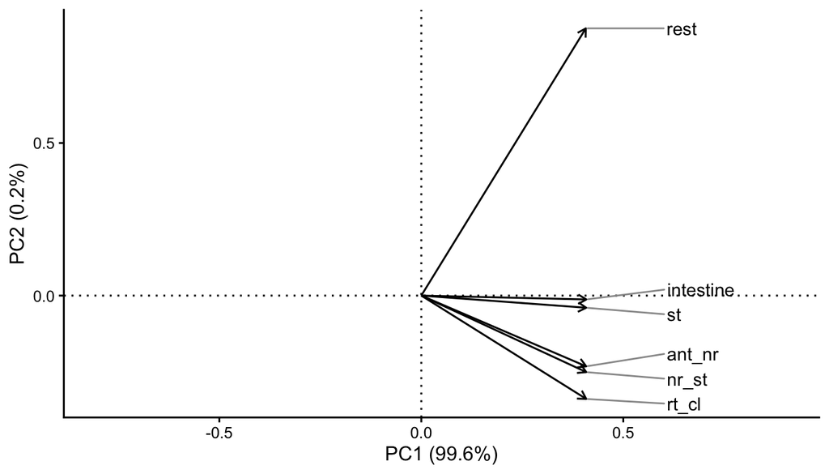

Expected result. The same image is in the project folder as `expected_figures/fig-loadings.png`.

How to read this

- Each arrow is one region. Its **loadings** (where the arrow points) say how much that region contributes to PC1 and PC2.
- All the arrows reach the same distance to the right: every region has a PC1 loading of about **0.41**. PC1 is all regions together, **overall size**.
- PC2 is dominated by **rest of body** (pointing up, 0.88), against the rectum/cloaca and the head regions (pointing down). A worm high on PC2 has a relatively long rest of body.
- Adult males have a longer rest of body than females (about 12% against 8%, Section 7), so males sit higher on PC2 in the score plot.

### 10.1 Removing size to see shape only

Because size dominates PC1, shape differences are hidden in later axes. A simple way to focus on shape is to divide out size: subtract each worm’s **mean log length** from every one of its log region lengths. What remains is the worm’s relative proportions. (This is the centred log-ratio from Section 7.2.)

What this analysis does, and why it matters

**What it does.** For each worm, it calculates one size number (the mean of its log region lengths) and subtracts it from every log length. Subtracting on the log scale is the same as dividing on the original scale, so what remains is each region **relative to the worm’s overall size**. A PCA of these values describes shape only.

**Why it matters.** Separating **size** from **shape** is the central problem of morphometrics. Two worms can differ simply because one is bigger, or because their body plans really differ. Ordinary PCA mixes the two, and size usually swamps everything else, as PC1’s 99.6% showed. Removing size first reveals the body-plan differences, such as stage and sex differences in proportions. Plotting shape against size then asks directly whether shape changes as worms grow.

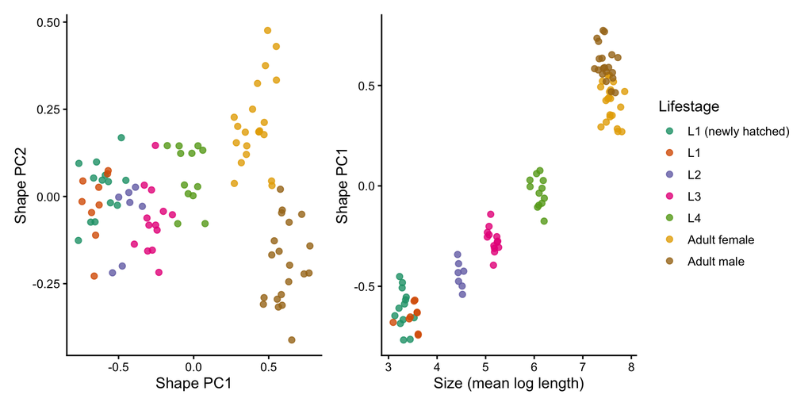

```r
shape_data <- pca_data |>
  mutate(across(all_of(pca_vars), log),                      # log every region length
         log_size = rowMeans(pick(all_of(pca_vars))),         # one size number per worm
         across(all_of(pca_vars), \(x) x - log_size))         # subtract it: what's left is shape

shape_pca <- shape_data |>
  select(all_of(pca_vars)) |>
  prcomp()                            # the last PC will have ~zero variance: ignore it

shape_scores <- bind_cols(shape_data |> select(sample, any_of("host_id"), lifestage, log_size),
                          as_tibble(shape_pca$x))

p_shape1 <- ggplot(shape_scores, aes(x = PC1, y = PC2, colour = lifestage)) +
  geom_point(size = 2, alpha = 0.8) +
  scale_colour_brewer(palette = "Dark2") +
  labs(x = "Shape PC1", y = "Shape PC2", colour = "Lifestage")

p_shape2 <- ggplot(shape_scores, aes(x = log_size, y = PC1, colour = lifestage)) +
  geom_point(size = 2, alpha = 0.8) +
  scale_colour_brewer(palette = "Dark2") +
  labs(x = "Size (mean log length)", y = "Shape PC1", colour = "Lifestage")

p_shape1 + p_shape2 + plot_layout(guides = "collect")
```

**Check your figure: click to see what it should look like**

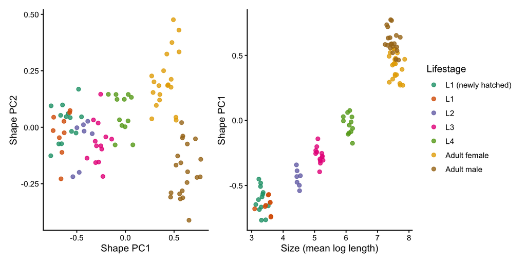

Expected result. The same image is in the project folder as `expected_figures/fig-shape-pca.png`.

The right-hand panel asks: **does shape change with size?** A clear trend means development changes body proportions (allometry), not just size.

How to read this

- With size removed, shape PC1 captures about **83%** of the remaining variation and shape PC2 about **10%**. Run `summary(shape_pca)` to see this.
- **Left panel.** Shape PC1 still runs from larvae (left) to adults (right): body proportions change step by step through development. Shape PC2 separates adult females (above) from males (below).
- **Right panel.** Shape PC1 rises steadily with size (correlation about 0.96): bigger worms have a different shape. This is the allometry from Section 8 seen again. Run `shape_pca$rotation` to see that shape PC1 is mainly the stichosome (+0.71) and rest of body (+0.37) against the anterior end to NR (−0.48).
- Within the adults (top right), shape differs mainly by **sex**, not by size: most of the size-related change in shape happens between stages.
- As with any PCA, an axis may come out mirror-imaged on another computer. That doesn’t change the interpretation.

PCA itself ignores mouse. To test group differences in PC scores while accounting for host, treat a PC score as the response in a mixed model, for example `lmer(PC1 ~ lifestage + (1 | host_id), data = filter(shape_scores, !is.na(host_id)))`. Section 13 introduces these models, and Exercise 4 tries this one.

## 11. Stichosome number: a structure that grows without adding cells

In *Trichuris*, the number of stichocytes (the gland cells that make up the stichosome) is **set early and stays roughly constant**, at about 50 to 60, from larva to adult. Yet the stichosome itself grows more than a hundred times longer between newly hatched L1 and adult (Section 8). The question here is therefore the opposite of the scaling section: not *how fast* something grows, but whether it **changes at all**. Showing that something stays the same needs a little care, statistically.

`st_number` is an approximate count, recorded for a subset of worms from L2 onwards. First, the counts per lifestage and a plot against body size:

```r
st_data <- worms |> drop_na(st_number)

st_data |>
  group_by(lifestage) |>
  summarise(n_worms = n(), median = median(st_number),
            min = min(st_number), max = max(st_number))
```

| lifestage | n_worms | median | min | max |
| --- | --- | --- | --- | --- |
| L2 | 6 | 56.0 | 52 | 58 |
| L3 | 8 | 54.5 | 51 | 59 |
| L4 | 11 | 57.0 | 50 | 60 |
| Adult female | 17 | 54.0 | 48 | 59 |
| Adult male | 13 | 56.0 | 48 | 60 |

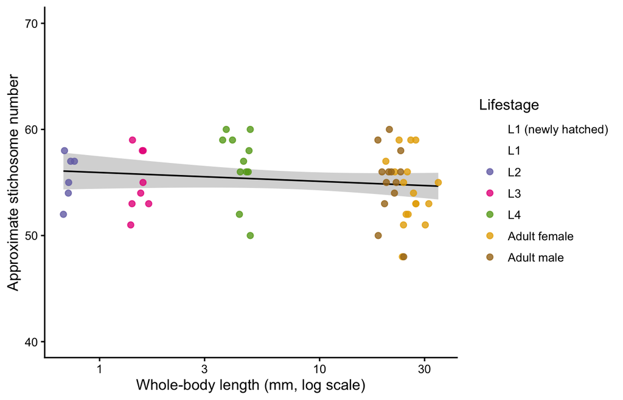

```r
ggplot(st_data, aes(x = wb_length / 1000, y = st_number)) +
  geom_smooth(method = "lm", formula = y ~ x, colour = "black", linewidth = 0.6) +  # straight line with its 95% CI band
  geom_point(aes(colour = lifestage), alpha = 0.8, size = 2) +
  scale_x_log10() +
  scale_colour_brewer(palette = "Dark2", drop = FALSE) +   # keep the same colours as the other figures
  expand_limits(y = c(40, 70)) +
  labs(x = "Whole-body length (mm, log scale)",
       y = "Approximate stichosome number", colour = "Lifestage")
```

**Check your figure: click to see what it should look like**

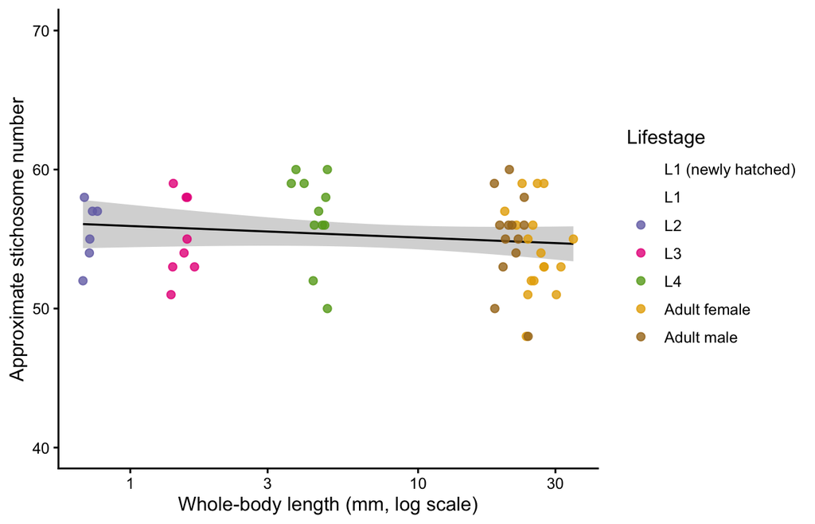

Expected result. The same image is in the project folder as `expected_figures/fig-stnumber.png`.

How to read this

- Each dot is one worm. The black line is a straight-line fit, and the grey band around it is its 95% confidence interval.
- The medians sit between **54 and 57** in every group, from L2 to adults, while body length goes from under 1 mm to over 30 mm. The line is essentially flat.
- The spread within each group (about 48 to 60) is similar at every stage: worms differ a little in their count, but not in a way that depends on size.
- There are no L1 worms because stichosome number wasn’t recorded for them. The L1 groups still appear in the legend so that the colours match the other figures.

### 11.1 Is it really constant? Putting a number on “no change”

What this analysis does, and why it matters

**What it does.** It fits a straight line of stichosome number against log10 body length, and reports the slope with its 95% confidence interval. The slope is the change in count for every **tenfold** increase in body length.

**Why not just look at the p-value?** A large p-value only says the data are compatible with no change. It doesn’t say the change is zero: a small study with very noisy counts would give a large p-value even if the number doubled. “Not significant” is **absence of evidence**, not **evidence of absence**.

**What to look at instead.** The confidence interval. If the whole interval is close to zero, the data rule out any change big enough to matter. That *is* evidence that the number stays the same. (A formal version of this idea is called an **equivalence test**: you decide in advance how big a change would matter, and check that the interval falls entirely inside that range.)

```r
fit_st_number <- lm(st_number ~ log10(wb_length), data = st_data)

broom::tidy(fit_st_number, conf.int = TRUE) |>
  filter(term == "log10(wb_length)")
```

| term | estimate | std.error | statistic | p.value | conf.low | conf.high |
| --- | --- | --- | --- | --- | --- | --- |
| log10(wb_length) | -0.8325803 | 0.7203349 | -1.155824 | 0.2529371 | -2.277389 | 0.6122286 |

**Check your output: click to see what it should look like**

```
# A tibble: 1 × 7
  term             estimate std.error statistic p.value conf.low conf.high
  <chr>               <dbl>     <dbl>     <dbl>   <dbl>    <dbl>     <dbl>
1 log10(wb_length)   -0.833     0.720     -1.16   0.253    -2.28     0.612
```

The slope is **−0.8 stichocytes per tenfold increase in length**, with a 95% CI of **−2.3 to 0.6**. The worms here span about a 50-fold range of length (1.7 tenfold steps), so even the ends of the interval allow a change of only about 4 cells out of 55. The count is effectively constant.

### 11.2 So how does the stichosome grow?

If the number of stichocytes stays the same while the stichosome gets longer, each stichocyte must get longer. Divide stichosome length by stichosome number to get the average length per cell:

```r
st_data |>
  drop_na(st) |>
  mutate(um_per_stichocyte = st / st_number) |>
  group_by(lifestage) |>
  summarise(n_worms           = n(),
            stichosome_um     = median(st),
            st_number         = median(st_number),
            um_per_stichocyte = median(um_per_stichocyte))
```

| lifestage | n_worms | stichosome_um | st_number | um_per_stichocyte |
| --- | --- | --- | --- | --- |
| L2 | 6 | 294.30 | 56.0 | 5.196686 |
| L3 | 8 | 660.15 | 54.5 | 11.715045 |
| L4 | 11 | 2181.00 | 57.0 | 38.068333 |
| Adult female | 17 | 13441.70 | 54.0 | 250.539286 |
| Adult male | 13 | 11727.10 | 56.0 | 211.078571 |

**Check your output: click to see what it should look like**

```
# A tibble: 5 × 5
  lifestage    n_worms stichosome_um st_number um_per_stichocyte
  <fct>          <int>         <dbl>     <dbl>             <dbl>
1 L2                 6          294.      56                5.20
2 L3                 8          660.      54.5             11.7
3 L4                11         2181       57               38.1
4 Adult female      17        13442.      54              251.
5 Adult male        13        11727.      56              211.
```

From L2 to adult, the stichosome gets about **40 times longer** (about 0.3 mm to 12 to 13 mm), while the number of cells stays at about 55. The length per stichocyte rises from about **5 µm to over 200 µm**: the stichosome grows by **enlarging a fixed set of cells**, not by adding new ones.

Like the other analyses in Sections 6 to 11, this treats every worm as independent and ignores mouse. With only a few worms per stage it is a description, not a definitive test. Section 13 shows how to bring mouse into a model like this one.

## 12. Worms within mice: the hierarchical structure

Every analysis so far (growth, body plan, scaling, sex differences, PCA and stichosome number) has treated each worm as an independent replicate. But the worms were collected from **mice**, and worms from the same mouse share a host environment (immune response, worm burden, how long the infection has run, diet and so on). That makes them more alike than worms from different mice.

### 12.1 How many mice, and how many worms per mouse?

```r
worms |>
  filter(!is.na(host_id)) |>
  count(dpi, host_id) |>
  group_by(dpi) |>
  summarise(n_mice        = n_distinct(host_id),
            n_worms       = sum(n),
            min_per_mouse = min(n),
            max_per_mouse = max(n))
```

| dpi | n_mice | n_worms | min_per_mouse | max_per_mouse |
| --- | --- | --- | --- | --- |
| 3 | 4 | 20 | 4 | 7 |
| 9 | 4 | 20 | 4 | 6 |
| 14 | 5 | 25 | 3 | 7 |
| 21 | 5 | 25 | 3 | 8 |
| 35 | 5 | 60 | 9 | 14 |
| 42 | 5 | 50 | 5 | 14 |

**Check your output: click to see what it should look like**

```
# A tibble: 6 × 5
    dpi n_mice n_worms min_per_mouse max_per_mouse
  <dbl>  <int>   <int>         <int>         <int>
1     3      4      20             4             7
2     9      4      20             4             6
3    14      5      25             3             7
4    21      5      25             3             8
5    35      5      60             9            14
6    42      5      50             5            14
```

Notice how few mice there are at each timepoint compared with the number of worms. **The number of mice, not the number of worms, is what limits how confidently you can compare timepoints.**

Some worms have no host at all. Check which:

```r
worms |> filter(is.na(host_id)) |> count(dpi, lifestage)
```

| dpi | lifestage | n |
| --- | --- | --- |
| 0 | L1 (newly hatched) | 30 |

These are the newly hatched larvae, which were hatched in vitro. They cannot be given a mouse random effect, and **mixed-effects models silently drop rows with a missing grouping variable**. In Section 13 we therefore filter them out explicitly, so you can see which worms each model uses. (If they share a hatching batch, a `batch` column could serve as their grouping variable instead.)

### 12.2 Is each mouse sampled at only one timepoint?

The models in Section 13 assume mice are *nested* within timepoints (each mouse contributes to a single dpi). Check that this holds:

```r
worms |>
  filter(!is.na(host_id)) |>
  group_by(host_id) |>
  summarise(n_dpi = n_distinct(dpi)) |>
  filter(n_dpi > 1)             # should return zero rows
```

| host_id | n_dpi |
| --- | --- |

Zero rows means the nesting is clean. If your real design has mice contributing at several timepoints, the model structure changes (see Section 17).

### 12.3 Do mice differ from each other?

To see mouse-to-mouse variation across all stages on one axis, express each worm’s length **relative to the average for its lifestage and timepoint** (1 = typical). If worms were independent, each mouse’s worms would scatter evenly around 1.

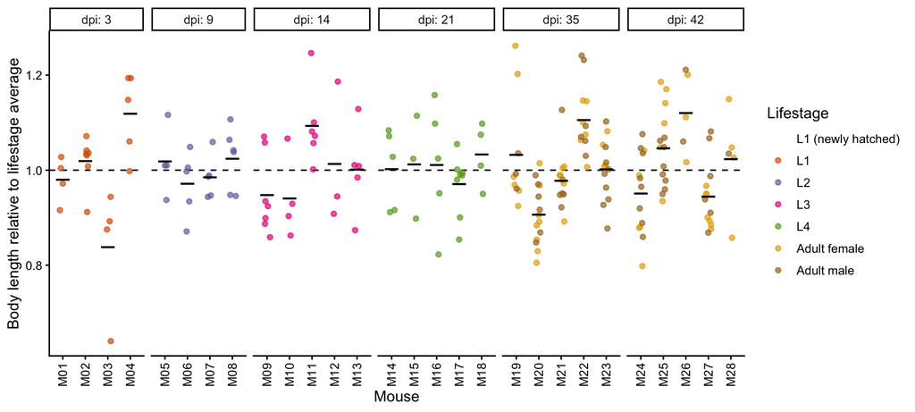

```r
worms <- worms |>
  group_by(dpi, lifestage) |>
  mutate(rel_length = wb_length / mean(wb_length)) |>
  ungroup()

worms |>
  filter(!is.na(host_id)) |>
  ggplot(aes(x = host_id, y = rel_length)) +
  geom_hline(yintercept = 1, linetype = "dashed") +
  geom_point(aes(colour = lifestage), alpha = 0.7,
             position = position_jitter(width = 0.15, height = 0, seed = 1)) +
  stat_summary(fun = mean, fun.min = mean, fun.max = mean,
               geom = "crossbar", width = 0.6, linewidth = 0.3) +   # mean per mouse
  scale_colour_brewer(palette = "Dark2", drop = FALSE) +
  facet_grid(. ~ dpi, scales = "free_x", space = "free_x", labeller = label_both) +
  labs(x = "Mouse", y = "Body length relative to lifestage average", colour = "Lifestage") +
  theme(axis.text.x = element_text(angle = 90, vjust = 0.5, hjust = 1))
```

**Check your figure: click to see what it should look like**

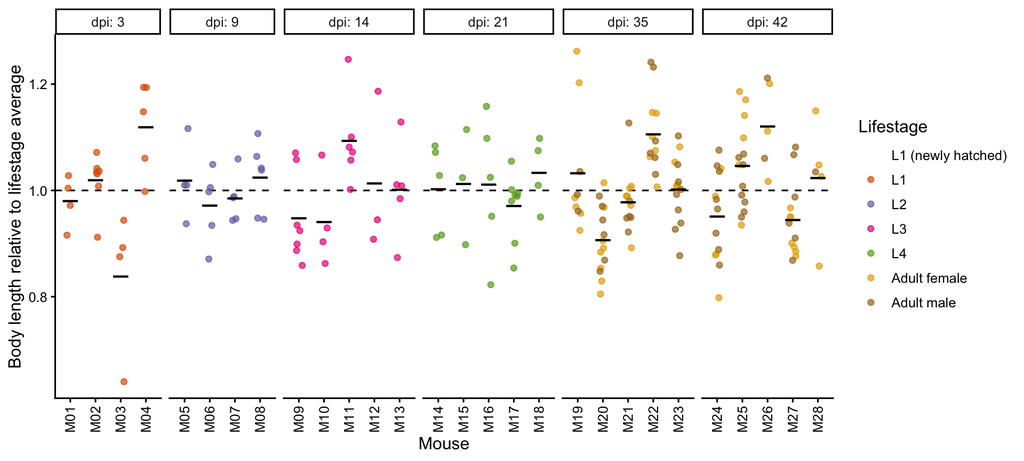

Expected result. The same image is in the project folder as `expected_figures/fig-mouse-clustering.png`.

How to read this

- Each column is one mouse, and each dot is one of its worms. Panels are timepoints (dpi).
- The y-axis is each worm’s length divided by the average for its lifestage and timepoint: **1** (dashed line) is average, **1.2** means 20% longer than average, and **0.8** means 20% shorter.
- The short horizontal bar is the **mean for that mouse**. If mice didn’t matter, every bar would sit close to 1.

Some mice have all their worms above 1 and others below. This is **clustering**: knowing which mouse a worm came from tells you something about its size. Ignoring that treats, say, 25 worms from 5 mice as if they were 25 independent pieces of evidence. This error is called **pseudoreplication**, and it makes confidence intervals too narrow and p-values too small.

## 13. Mixed-effects models: accounting for host

### 13.1 The idea

An ordinary linear model (`lm`) assumes every observation is independent. A **mixed-effects model** adds a **random effect** that says “observations from the same mouse share a mouse-specific shift”:

- **Fixed effects** are the things you want to estimate and compare: sex, timepoint, body length.
- **Random effects** describe grouping structure you want to account for but are not interested in comparing mouse by mouse. Here, mouse.

In R’s `lme4` syntax, `(1 | host_id)` means “a separate baseline (intercept) for each mouse, drawn from a common distribution”. The model then splits variation into **between-mouse** and **within-mouse** components.

### 13.2 Fit the models

We model the **log** of length, so effects are ratios (“females are 25% longer”). We fit the ordinary model and the mixed model side by side.

What this analysis does, and why it matters

**What a linear model does.** `lm()` predicts a response (here log length) from one or more **predictors** (here sex and timepoint). The formula `sex * dpi_f` is shorthand for `sex + dpi_f + sex:dpi_f`: an effect of sex, an effect of timepoint, and an **interaction** (does the sex difference depend on timepoint?). The model estimates each effect and its standard error, and gives a p-value for each.

**What the mixed model adds.** `lmer()` fits the same model, plus `(1 | host_id)`: every mouse gets its own baseline. The model then knows which worms share a mouse, so it can separate variation between mice from variation within mice.

**Why log length?** Differences between groups in body size are usually proportional (females 25% longer), not fixed amounts (females 5 mm longer), and larger groups usually vary more. On the log scale both problems go away: effects become ratios, and the spread is similar across groups, which the model assumes.

**Why it matters.** Treating 110 worms from 10 mice as 110 independent animals overstates how much evidence you have. Standard errors come out too small, and p-values too small, especially for anything compared *between* mice, such as timepoint. That is how false “significant” results get published. A mixed model gives each comparison the precision its design really supports. Most reviewers now expect one whenever animals are nested within hosts, cages or batches.

**p-values.** A **p-value** is the probability of seeing an effect at least this large if there were really no effect. A small p-value (conventionally below 0.05) means the data would be surprising under “no effect”. It does **not** tell you how big or important the effect is. Report the estimate and its confidence interval as well, which is what the rest of this section does.

```r
fit_lm  <- lm(log(wb_length) ~ sex * dpi_f, data = adults)
fit_lmm <- lmer(log(wb_length) ~ sex * dpi_f + (1 | host_id), data = adults)

summary(fit_lmm)
```

```
## Linear mixed model fit by REML. t-tests use Satterthwaite's method [
## lmerModLmerTest]
## Formula: log(wb_length) ~ sex * dpi_f + (1 | host_id)
##    Data: adults
##
## REML criterion at convergence: -209.7
##
## Scaled residuals:
##      Min       1Q   Median       3Q      Max
## -2.19444 -0.73063  0.03932  0.57932  2.67815
##
## Random effects:
##  Groups   Name        Variance Std.Dev.
##  host_id  (Intercept) 0.004584 0.06771
##  Residual             0.006075 0.07794
## Number of obs: 110, groups:  host_id, 10
##
## Fixed effects:
##                 Estimate Std. Error       df t value Pr(>|t|)
## (Intercept)     10.12126    0.03351  9.28581 302.013   <2e-16 ***
## sexMale         -0.24907    0.02063 99.15110 -12.075   <2e-16 ***
## dpi_f42          0.15226    0.04790  9.66897   3.179   0.0103 *
## sexMale:dpi_f42  0.01405    0.03063 99.51422   0.459   0.6475
## ---
## Signif. codes:  0 '***' 0.001 '**' 0.01 '*' 0.05 '.' 0.1 ' ' 1
##
## Correlation of Fixed Effects:
##             (Intr) sexMal dp_f42
## sexMale     -0.303
## dpi_f42     -0.700  0.212
## sxMl:dp_f42  0.204 -0.673 -0.303
```

**Check your output: click to see what it should look like**

```
Linear mixed model fit by REML. t-tests use Satterthwaite's method [
lmerModLmerTest]
Formula: log(wb_length) ~ sex * dpi_f + (1 | host_id)
   Data: adults

REML criterion at convergence: -209.7

Scaled residuals:
     Min       1Q   Median       3Q      Max
-2.19444 -0.73063  0.03932  0.57932  2.67815

Random effects:
 Groups   Name        Variance Std.Dev.
 host_id  (Intercept) 0.004584 0.06771
 Residual             0.006075 0.07794
Number of obs: 110, groups:  host_id, 10

Fixed effects:
                Estimate Std. Error       df t value Pr(>|t|)
(Intercept)     10.12126    0.03351  9.28581 302.013   <2e-16 ***
sexMale         -0.24907    0.02063 99.15110 -12.075   <2e-16 ***
dpi_f42          0.15226    0.04790  9.66897   3.179   0.0103 *
sexMale:dpi_f42  0.01405    0.03063 99.51422   0.459   0.6475
---
Signif. codes:  0 ‘***’ 0.001 ‘**’ 0.01 ‘*’ 0.05 ‘.’ 0.1 ‘ ’ 1

Correlation of Fixed Effects:
            (Intr) sexMal dp_f42
sexMale     -0.303
dpi_f42     -0.700  0.212
sxMl:dp_f42  0.204 -0.673 -0.303
```

The “Random effects” block shows the **variance between mice** (`host_id`) and the leftover **residual variance** (worm-to-worm variation within a mouse).

How to read this

This is the most information-dense output in the tutorial. Take it one block at a time.

**Random effects.** The variance between mice is 0.0046 and the residual (within-mouse) variance is 0.0061. Section 13.4 turns these into one number, the ICC.

**Fixed effects.** There is one row per term. Because we modelled **log(length)**, each estimate is a difference on the log scale. Applying `exp()` turns it into a **ratio**, which is easier to talk about.

| Row | Estimate | What it means | As a ratio |
| --- | --- | --- | --- |
| `(Intercept)` | 10.12 | Predicted log length for the **reference group**: females at 35 dpi (R uses the first level of each factor as the reference) | exp(10.12) ≈ 24,900 µm, so about 24.9 mm |
| `sexMale` | −0.249 | Males compared with females, at 35 dpi | exp(−0.249) = 0.78: males are about **22% shorter** |
| `dpi_f42` | 0.152 | Females at 42 dpi compared with 35 dpi | exp(0.152) = 1.16: about **16% longer** |
| `sexMale:dpi_f42` | 0.014 | The **interaction**: does the sex difference change between 35 and 42 dpi? | Tiny, and p = 0.65: **no evidence** that it changes |

**The columns.** `Std. Error` is how precisely each estimate is known (smaller is more precise). `t value` is the estimate divided by its standard error. `Pr(>|t|)` is the p-value. `df` (degrees of freedom) is worth a closer look: `sexMale` has about 99, close to the number of **worms**, but `dpi_f42` has only about 10, close to the number of **mice**. That is the model recognising that timepoints are compared between mice, so only the mice count as replicates.

The “Correlation of Fixed Effects” block at the bottom can be ignored for now.

To see every fixed effect as a ratio at once, run `exp(fixef(fit_lmm))`.

### 13.3 How does accounting for mouse change the answers?

```r
# coef(summary(...)) is the model's coefficient table; as_tibble() makes it a tibble
se_lm   <- coef(summary(fit_lm))  |> as_tibble(rownames = "term") |> select(term, se_lm   = `Std. Error`)
se_lmer <- coef(summary(fit_lmm)) |> as_tibble(rownames = "term") |> select(term, se_lmer = `Std. Error`)

se_compare <- left_join(se_lm, se_lmer, by = "term")
se_compare
```

| term | se_lm | se_lmer |
| --- | --- | --- |
| (Intercept) | 0.01807198 | 0.03351263 |
| sexMale | 0.02555764 | 0.02062606 |
| dpi_f42 | 0.02680508 | 0.04789909 |
| sexMale:dpi_f42 | 0.03790810 | 0.03062521 |

**Check your output: click to see what it should look like**

```
# A tibble: 4 × 3
  term             se_lm se_lmer
  <chr>            <dbl>   <dbl>
1 (Intercept)     0.0181  0.0335
2 sexMale         0.0256  0.0206
3 dpi_f42         0.0268  0.0479
4 sexMale:dpi_f42 0.0379  0.0306
```

What to expect, and why:

- **`sexMale`** is compared *within* each mouse. Removing between-mouse variation from the comparison usually makes the standard error **smaller** under the mixed model.
- **`dpi_f42`** is compared *between* mice (different mice at 35 and 42 dpi). The mixed model usually gives a **larger** standard error, because the real replication is the number of mice. The ordinary model was overconfident.

So a mixed model is not simply “more conservative”. It gives each comparison the precision its design really deserves.

Now estimate the female/male ratio at each timepoint under both models:

What this analysis does, and why it matters

**What it does.** `emmeans()` (estimated marginal means) asks a fitted model for its **predicted mean for each group**, with a confidence interval. Here it gives the predicted mean log length for each sex at each timepoint. `pairs()` then compares the sexes within each timepoint, and `type = "response"` converts the answer from the log scale back to a ratio (female ÷ male).

**Why not just use the raw group means?** Raw means ignore the model. They don’t know that worms from the same mouse are related, so their standard errors are wrong. With **unbalanced** data (different numbers of worms per mouse or per group), they can also be pulled towards whichever mice contributed the most worms. Model-based means use the whole model, so their intervals reflect the real design.

**Why it matters.** Biologists usually want an answer like “females are 27% longer (95% CI 23 to 34%)” rather than a coefficient table. `emmeans` produces exactly that, from the right model, and handles the back-transformation from logs for you.

```r
sex_ratio <- function(model, label) {
  emmeans(model, ~ sex | dpi_f, lmer.df = "satterthwaite") |>   # lmer.df is ignored for lm
    pairs() |>
    summary(type = "response", infer = TRUE) |>   # back-transform from log to ratio
    as_tibble() |>
    mutate(model = label)
}

bind_rows(sex_ratio(fit_lm,  "lm (ignores mouse)"),
          sex_ratio(fit_lmm, "lmer (mouse random effect)")) |>
  select(model, dpi_f, contrast, ratio, lower.CL, upper.CL)
```

| model | dpi_f | contrast | ratio | lower.CL | upper.CL |
| --- | --- | --- | --- | --- | --- |
| lm (ignores mouse) | 35 | Female / Male | 1.277817 | 1.214682 | 1.344233 |
| lm (ignores mouse) | 42 | Female / Male | 1.273337 | 1.204584 | 1.346015 |
| lmer (mouse random effect) | 35 | Female / Male | 1.282827 | 1.231386 | 1.336417 |
| lmer (mouse random effect) | 42 | Female / Male | 1.264933 | 1.209377 | 1.323041 |

**Check your output: click to see what it should look like**

```
# A tibble: 4 × 6
  model                      dpi_f contrast      ratio lower.CL upper.CL
  <chr>                      <fct> <fct>         <dbl>    <dbl>    <dbl>
1 lm (ignores mouse)         35    Female / Male  1.28     1.21     1.34
2 lm (ignores mouse)         42    Female / Male  1.27     1.20     1.35
3 lmer (mouse random effect) 35    Female / Male  1.28     1.23     1.34
4 lmer (mouse random effect) 42    Female / Male  1.26     1.21     1.32
```

A ratio of 1.25 means females are 25% longer than males. Compare the confidence intervals between the two models.

How to read this

- Both models give almost the same ratio: about **1.27**, so females are roughly 27% longer than males at both timepoints.
- The mixed model’s intervals are slightly **narrower** (for example 1.23 to 1.34 against 1.21 to 1.34 at 35 dpi). That is what Section 13.3 predicted: sex is compared *within* mice, so removing the mouse-to-mouse variation sharpens the comparison.
- Both intervals are far from 1 (no difference), so the sex difference is clear whichever model you use.

### 13.4 How much variation is between mice? (ICC)

The **intraclass correlation coefficient (ICC)** is the proportion of total variation that is between mice. An ICC near 0 means worms from the same mouse are no more alike than worms from different mice. A high ICC means mouse matters a lot.

What this analysis does, and why it matters

**What it does.** It takes the two variances from the model’s “Random effects” block and divides the between-mouse variance by the total: ICC = mouse variance ÷ (mouse variance + residual variance).

**Why it matters.** The ICC tells you how much the clustering matters, and so how to design the next experiment. With a high ICC, extra worms from the same mice add little information: the worms mostly repeat what their mouse already told you. To gain precision you need **more mice**. With an ICC near 0, worms behave almost independently, and measuring more worms per mouse is nearly as good as adding mice. Reporting the ICC also lets other researchers plan their sample sizes.

```r
VarCorr(fit_lmm) |>
  as_tibble() |>                       # one row per variance component: host_id, Residual
  summarise(icc = round(vcov[grp == "host_id"] / sum(vcov), 2))
```

| icc |
| --- |
| 0.43 |

**Check your output: click to see what it should look like**

```
# A tibble: 1 × 1
    icc
  <dbl>
1  0.43
```

In the simulation, mouse and individual variation were set to similar sizes, so the ICC should be moderate. Here it is **0.43**: after allowing for sex and timepoint, 43% of the variation in adult length is between mice, and 57% is between worms from the same mouse. With real data, a high ICC means pseudoreplication would have been a serious problem.

### 13.5 Check the model

Two quick checks: the residuals should form an even cloud, and the mouse effects should be roughly normally distributed.

What this analysis does, and why it matters

**What it does.** Every model makes assumptions about the data. For this one: the leftover variation (the **residuals**) is roughly normal and has a similar spread everywhere, and the mouse effects are roughly normal. These plots let you see whether that is reasonable.

**Why it matters.** The standard errors, confidence intervals and p-values are only trustworthy if the assumptions roughly hold. A model can run without any error message and still give misleading answers, for example if one group is far more variable than the others or a few extreme values dominate. Checking takes a minute, and it is what a careful reviewer will ask about.

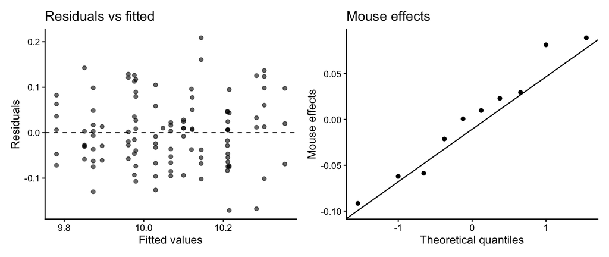

```r
diag_df <- tibble(fitted = fitted(fit_lmm), resid = resid(fit_lmm))
re_df   <- ranef(fit_lmm) |> as_tibble() |> rename(effect = condval)   # one row per mouse

p_d1 <- ggplot(diag_df, aes(fitted, resid)) +
  geom_point(alpha = 0.6) +
  geom_hline(yintercept = 0, linetype = "dashed") +
  labs(x = "Fitted values", y = "Residuals", title = "Residuals vs fitted")

p_d2 <- ggplot(re_df, aes(sample = effect)) +
  stat_qq() +
  stat_qq_line() +
  labs(x = "Theoretical quantiles", y = "Mouse effects", title = "Mouse effects")

p_d1 | p_d2
```

**Check your figure: click to see what it should look like**

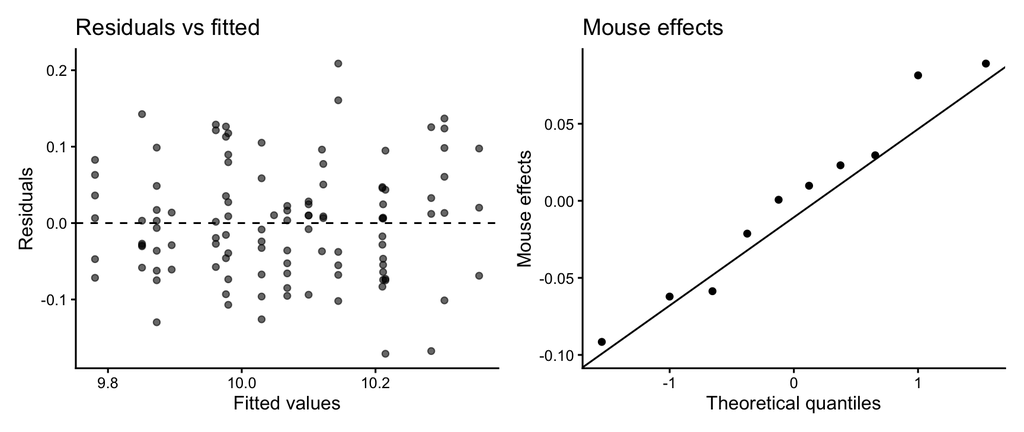

Expected result. The same image is in the project folder as `expected_figures/fig-lmm-diag.png`.

With only a handful of mice, the mouse-effect plot will always look rough. Look for gross problems, not perfection.

How to read this

- **Left (residuals against fitted values).** Each dot is one worm. Its residual is how far its actual value is from the model’s prediction. You want an **even band around 0 with no pattern**, as here. The vertical stripes are normal: worms of the same sex from the same mouse share a fitted value.
- Warning signs: a **funnel** (spread growing with the fitted value, which often means the data need a log scale), a **curve** (the model is missing something), or a few points **far from the rest** (check those worms in the data).
- **Right (Q-Q plot of mouse effects).** Each dot is one mouse (10 here). If the mouse effects are roughly normally distributed, the dots lie near the line. Here they do. With 10 points, small wiggles mean nothing: look for one mouse far off the line.

### 13.6 More worms per mouse is not more mice

Back to growth. We compare estimated mean length for each lifestage-and-timepoint group with and without the mouse random effect. **First remove worms with no host** (the newly hatched larvae), so that both models use exactly the same rows. Otherwise `lmer` would drop them silently and the two models would not be comparable.

```r
worms_g <- worms |>
  filter(!is.na(host_id)) |>                       # same rows for both models
  arrange(dpi, lifestage) |>
  mutate(group = paste0(lifestage, ", ", dpi, " dpi"),
         group = factor(group, levels = unique(group)))

fit_g_lm  <- lm(log(wb_length) ~ group, data = worms_g)
fit_g_lmm <- lmer(log(wb_length) ~ group + (1 | host_id), data = worms_g)

est <- bind_rows(
  emmeans(fit_g_lm,  ~ group) |> summary(type = "response") |> as_tibble() |>
    mutate(model = "lm (ignores mouse)"),
  emmeans(fit_g_lmm, ~ group, lmer.df = "satterthwaite") |> summary(type = "response") |> as_tibble() |>
    mutate(model = "lmer (mouse random effect)")
)
```

The groups differ in size by a factor of 100, so on one shared axis every interval would shrink to a dot. Give each group its own panel and y-axis instead, so you can compare the **widths** of the two intervals:

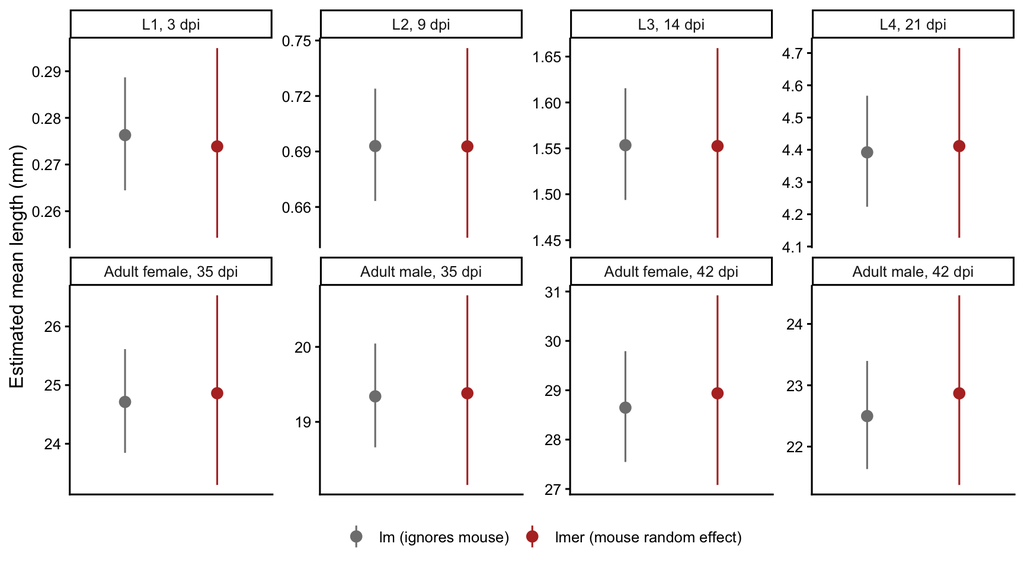

```r
ggplot(est, aes(x = model, y = response / 1000,
                ymin = lower.CL / 1000, ymax = upper.CL / 1000, colour = model)) +
  geom_pointrange() +
  facet_wrap(~ group, scales = "free_y", nrow = 2) +   # each group gets its own y-axis
  scale_colour_manual(values = c("grey50", "#B5322B")) +
  labs(x = NULL, y = "Estimated mean length (mm)", colour = NULL) +
  theme(axis.text.x  = element_blank(),
        axis.ticks.x = element_blank(),
        legend.position = "bottom")
```

**Check your figure: click to see what it should look like**

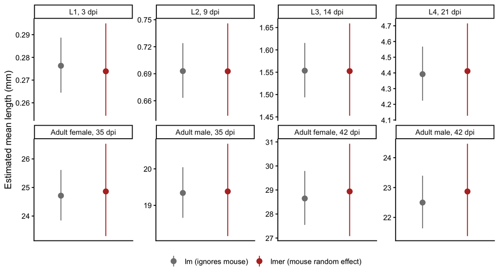

Expected result. The same image is in the project folder as `expected_figures/fig-lmm-growth.png`.

In every panel the mixed-model interval (red) is wider. With only 4 to 5 mice per timepoint, a mean based on 20 to 30 worms is really supported by 4 to 5 independent mice, and the wider interval reflects that. **To narrow it, you need more mice, not more worms per mouse.**

### 13.7 A scaling slope with a mouse random effect

Back to allometry (Section 8). Here is the stichosome slope fitted with and without a mouse random effect, again using the same rows (worms with a host) for both:

```r
st_only <- seg_long |>
  filter(segment == "Stichosome", !is.na(host_id))

fit_st_lm  <- lm(log10(length_um) ~ log10(wb_length), data = st_only)
fit_st_lmm <- lmer(log10(length_um) ~ log10(wb_length) + (1 | host_id), data = st_only)

slope_row <- function(model, label) {
  estimates <- coef(summary(model)) |> as_tibble(rownames = "term")
  intervals <- confint(model, method = "Wald") |> as_tibble(rownames = "term")   # lm() ignores `method`

  left_join(estimates, intervals, by = "term") |>
    filter(term == "log10(wb_length)") |>
    transmute(model = label, slope = Estimate, conf.low = `2.5 %`, conf.high = `97.5 %`)
}

bind_rows(slope_row(fit_st_lm,  "lm (ignores mouse)"),
          slope_row(fit_st_lmm, "lmer (mouse random effect)"))
```

| model | slope | conf.low | conf.high |
| --- | --- | --- | --- |
| lm (ignores mouse) | 1.084767 | 1.077132 | 1.092403 |
| lmer (mouse random effect) | 1.083947 | 1.073694 | 1.094199 |

**Check your output: click to see what it should look like**

```
# A tibble: 2 × 4
  model                      slope conf.low conf.high
  <chr>                      <dbl>    <dbl>     <dbl>
1 lm (ignores mouse)          1.08     1.08      1.09
2 lmer (mouse random effect)  1.08     1.07      1.09
```

### 13.8 Practical notes

- **Report both counts.** State the number of worms *and* the number of mice per group (for example “n = 25 worms from 5 mice”).
- **Missing grouping values.** `lmer` silently drops rows where the grouping variable is `NA`. Filter them out yourself, as above, and say how many worms were excluded.
- **“Singular fit” warnings** mean the model estimated the between-mouse variance as essentially zero. Often this just means there is too little mouse-to-mouse variation or too few mice to estimate it. The ordinary model may then be adequate, but keeping the random effect is still the honest description of the design.
- **Few mice.** Random-effect variances are poorly estimated with fewer than about five mice per group. Interpret them cautiously.
- **Degrees of freedom.** `lmerTest` and `emmeans` use approximations (Satterthwaite or Kenward-Roger) that reflect the number of mice. Report which was used. This tutorial sets `lmer.df = "satterthwaite"` in `emmeans()` so that everyone gets the same numbers: otherwise `emmeans` picks Kenward-Roger when the `pbkrtest` package happens to be installed, and Satterthwaite (with a message) when it isn’t.
- **Write the model down.** For example: “log body length ~ sex × timepoint + (1 | mouse), fitted with lme4 and lmerTest in R”.

## 14. Growth curves: modelling length over time

Section 6 described growth one sampling day at a time, and Section 13.6 estimated a mean for each group. Neither says anything about **between** the sampling days, or gives a single summary of how the worms grow. A **growth curve** does: it fits one smooth line through all the timepoints, and its parameters are things a biologist wants to know, such as the final adult size and when growth is fastest.

### 14.1 The idea

On a log scale (Section 6), body length follows an S-shape over time: slow in the first days, fastest in the middle of larval development, then levelling off in adults. A **logistic curve** has exactly that shape. On the log scale it has four parameters:

| Parameter | What it is | Read from the plot in Section 6 |
| --- | --- | --- |
| `lo` | The lower plateau, the size the curve levels off towards on the left | below the L1 larvae: log(200 µm) ≈ 5.3 |
| `hi` | The upper plateau: **final adult size** | about adult size: log(30,000 µm) ≈ 10.3 |
| `xmid` | The day half way between the plateaus, when **relative growth is fastest** | somewhere around 20 dpi |
| `scal` | How spread out growth is in time: larger means slower, more drawn-out growth | about 5 days |

We add one more parameter, `male_diff`, which lowers the upper plateau for males. Larvae can’t be sexed, so they all sit on the same curve, and the sex difference is estimated from the adults.

What this analysis does, and why it matters

**What it does.** It fits a **nonlinear model**: the curve’s shape is fixed in advance (here, logistic), and R finds the parameter values that bring the curve closest to the data (least squares, as for a straight line). Unlike `lm()`, there is no formula for the answer, so R searches step by step, starting from **starting values** that you supply. Then it fits the same curve with a mouse random effect, just as `lmer()` did in Section 13.

**Why it matters.** The parameters summarise the whole growth trajectory in a few numbers with confidence intervals: “females level off at about 45 mm, males about 23% shorter, and relative growth peaks at about 14 dpi”. These numbers can be compared directly between groups, for example between mouse strains, or treated and untreated mice, which is often the real question. The curve also gives the **growth rate** at any day, including days you didn’t sample.

**The catch.** A curve is only as good as the timepoints behind it. Anything it says beyond your last sampling day is an **extrapolation**, and the upper plateau usually is one (Section 14.5).

We use the worms with a mouse (`worms_g` from Section 13.6), so the newly hatched larvae are left out, and add a 0/1 column for males:

```r
# the logistic curve on the log scale, written as an R function
growth_curve <- function(dpi, lo, hi, xmid, scal) {
  lo + (hi - lo) / (1 + exp((xmid - dpi) / scal))
}

gc_data <- worms_g |>
  mutate(male = as.numeric(sex %in% "Male"))   # 1 for adult males, 0 for everyone else
```

### 14.2 Fit the curve, ignoring mouse

`nls()` fits a nonlinear model by least squares. The formula says: log length follows `growth_curve()`, with the upper plateau lowered by `male_diff` for males. `start` gives the starting values read off the Section 6 plot (in the table above).

```r
fit_gc_nls <- nls(log(wb_length) ~ growth_curve(dpi, lo, hi + male_diff * male, xmid, scal),
                  data  = gc_data,
                  start = c(lo = 5.3, hi = 10.3, xmid = 20, scal = 5, male_diff = -0.25))
coef(fit_gc_nls)
```

```
##         lo         hi       xmid       scal  male_diff
##  4.4865922 10.5837058 15.2919063  8.6310004 -0.2355828
```

**Check your output: click to see what it should look like**

```
       lo        hi      xmid      scal male_diff
 4.4865922 10.5837058 15.2919063  8.6310004 -0.2355828
```

The starting values were rough, but the fit moved well away from them: `xmid` from 20 to about 15 days, `scal` from 5 to about 9. That is normal. Starting values only need to be close enough for R to find its way.

If the fit fails

`nls()` can stop with errors such as `singular gradient` or `step factor reduced below minFactor`. These almost always mean the starting values are too far off, or the curve has more parameters than the data can support. Plot the data, read better starting values off the plot, and try again. If it still fails, try a simpler curve. **Always plot the fitted curve over the data** (Section 14.4): a curve can converge and still be nonsense.

### 14.3 Add the mouse

As in Section 13, worms from the same mouse resemble each other. `nlme()` from the **nlme** package (installed with R, so there is nothing new to install) fits nonlinear **mixed** models. We add a parameter `mouse`, a random shift of log length for each mouse, which is the same “each mouse has its own baseline” idea as `(1 | host_id)`. The estimates from `nls()` are the starting values.

```r
fit_gc <- nlme::nlme(log(wb_length) ~ growth_curve(dpi, lo, hi + male_diff * male, xmid, scal) + mouse,
                     data   = gc_data,
                     fixed  = lo + hi + xmid + scal + male_diff ~ 1,   # one value of each for everyone
                     random = mouse ~ 1 | host_id,                     # a shift for each mouse
                     start  = coef(fit_gc_nls))

nlme::intervals(fit_gc, which = "fixed")
```

```
## Approximate 95% confidence intervals
##
##  Fixed effects:
##                lower       est.      upper
## lo         3.3368237  4.0937149  4.8506060
## hi        10.4745987 10.7174892 10.9603797
## xmid      12.5540939 14.4966223 16.4391508
## scal       7.8620111  9.6892411 11.5164712
## male_diff -0.2963098 -0.2611253 -0.2259409
```

**Check your output: click to see what it should look like**

```
Approximate 95% confidence intervals

 Fixed effects:
               lower       est.      upper
lo         3.3368237  4.0937149  4.8506060
hi        10.4745987 10.7174892 10.9603797
xmid      12.5540939 14.4966223 16.4391508
scal       7.8620111  9.6892411 11.5164712
male_diff -0.2963098 -0.2611253 -0.2259409
```

(We write `nlme::nlme()` and `nlme::intervals()`, naming the package each time, rather than loading nlme with `library()`. Loading it would hide some lme4 functions used in Section 13 behind nlme versions with the same name.)

Logs are hard to talk about, so turn the parameters into biological quantities:

```r
gc_ci <- nlme::intervals(fit_gc, which = "fixed")$fixed   # columns lower, est., upper

tibble(
  quantity = c("Final length, females (mm)",
               "Final length, males / females",
               "Day of fastest relative growth (dpi)",
               "Peak growth rate (% longer per day)"),
  estimate = c(exp(gc_ci["hi", "est."]) / 1000,
               exp(gc_ci["male_diff", "est."]),
               gc_ci["xmid", "est."],
               100 * (gc_ci["hi", "est."] - gc_ci["lo", "est."]) / (4 * gc_ci["scal", "est."])),
  lower    = c(exp(gc_ci["hi", "lower"]) / 1000, exp(gc_ci["male_diff", "lower"]), gc_ci["xmid", "lower"], NA),
  upper    = c(exp(gc_ci["hi", "upper"]) / 1000, exp(gc_ci["male_diff", "upper"]), gc_ci["xmid", "upper"], NA)
)
```

| quantity | estimate | lower | upper |
| --- | --- | --- | --- |
| Final length, females (mm) | 45.1384270 | 35.404659 | 57.5482895 |
| Final length, males / females | 0.7701844 | 0.743557 | 0.7977653 |
| Day of fastest relative growth (dpi) | 14.4966223 | 12.554094 | 16.4391508 |
| Peak growth rate (% longer per day) | 17.0905395 | NA | NA |

**Check your output: click to see what it should look like**

```
# A tibble: 4 × 4
  quantity                             estimate  lower  upper
  <chr>                                   <dbl>  <dbl>  <dbl>
1 Final length, females (mm)             45.1   35.4   57.5
2 Final length, males / females           0.770  0.744  0.798
3 Day of fastest relative growth (dpi)   14.5   12.6   16.4
4 Peak growth rate (% longer per day)    17.1   NA     NA
```

How to read this

- **Final length.** Females level off at about **45 mm** (95% CI 35 to 58 mm). The interval is wide, and the whole estimate lies beyond the data (Section 14.5).
- **Sex.** Males level off at **0.77** of the female length, about 23% shorter (CI 20 to 26%). That agrees with Section 13.3, where females were about 27% longer than males (1 ÷ 1.27 = 0.79).
- **Fastest relative growth** is at about **14.5 dpi** (CI 12.6 to 16.4), around the L3 stage, when the worms get about **17% longer every day**.
- The peak growth rate has no confidence interval here, because it combines three parameters (`hi`, `lo` and `scal`). Getting one needs more advanced methods, such as bootstrapping.
- Compare with `nls()` (Section 14.2): the estimates moved a little once the mouse was included, and the intervals now reflect the number of mice, as in Section 13.

### 14.4 Plot the curve

Predict the curve on a fine grid of days, for females and males, then draw it over the data. Panel B shows the **growth rate**: how much the log length changes from one day to the next, times 100, which is roughly “% longer per day”. We draw the curves to 60 dpi on purpose, to show what the model claims beyond the data.

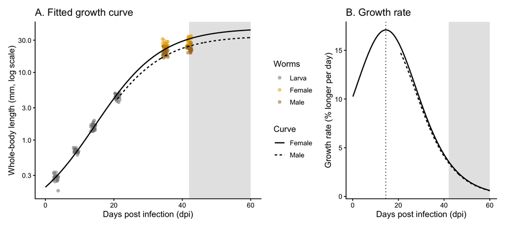

```r
gc_est <- nlme::fixef(fit_gc)   # the fitted parameters: lo, hi, xmid, scal, male_diff

gc_pred <- expand_grid(dpi = seq(0, 60, by = 0.1), sex = c("Female", "Male")) |>
  mutate(male    = as.numeric(sex == "Male"),
         log_len = growth_curve(dpi, gc_est["lo"], gc_est["hi"] + gc_est["male_diff"] * male,
                                gc_est["xmid"], gc_est["scal"])) |>
  group_by(sex) |>
  mutate(rate = 100 * (log_len - lag(log_len)) / 0.1) |>   # change in log length per day, as %
  ungroup() |>
  filter(sex == "Female" | dpi >= 21)    # sexes can't be told apart before L4 (21 dpi)

# grey band: days after the last sampling day
beyond_data <- annotate("rect", xmin = 42, xmax = 60, ymin = -Inf, ymax = Inf, fill = "grey90")

p_gc1 <- ggplot() +
  annotate("rect", xmin = 42, xmax = 60, ymin = 0, ymax = Inf, fill = "grey90") +   # 0 is -Inf on a log axis
  geom_point(data = gc_data, aes(dpi, wb_length / 1000, colour = coalesce(as.character(sex), "Larva")),
             alpha = 0.5, position = position_jitter(width = 0.8, height = 0, seed = 1)) +
  geom_line(data = gc_pred, aes(dpi, exp(log_len) / 1000, linetype = sex), linewidth = 0.8) +
  scale_y_log10() +
  scale_colour_manual(values = c(Larva = "grey50", Female = "#E6AB02", Male = "#A6761D"),
                      breaks = c("Larva", "Female", "Male")) +
  labs(x = "Days post infection (dpi)", y = "Whole-body length (mm, log scale)",
       colour = "Worms", linetype = "Curve", title = "A. Fitted growth curve")

p_gc2 <- ggplot(filter(gc_pred, !is.na(rate)), aes(dpi, rate, linetype = sex)) +
  beyond_data +
  geom_line(linewidth = 0.8) +
  geom_vline(xintercept = gc_est["xmid"], linetype = "dotted") +
  labs(x = "Days post infection (dpi)", y = "Growth rate (% longer per day)",
       linetype = "Curve", title = "B. Growth rate") +
  theme(legend.position = "none")

p_gc1 + p_gc2 + plot_layout(widths = c(3, 2))
```

**Check your figure: click to see what it should look like**

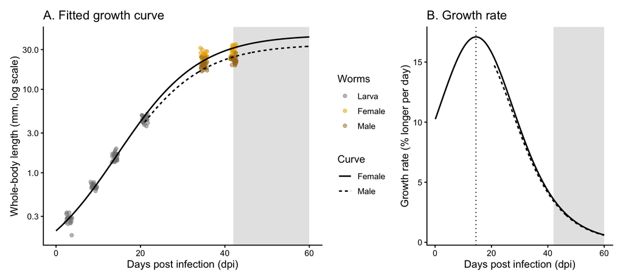

Expected result. The same image is in the project folder as `expected_figures/fig-growthcurve.png`.

How to read this

- **Panel A.** The solid line is the female curve, and the dashed line the male curve. The male curve is drawn from 21 dpi (L4), the first stage that can be sexed. The sex difference was estimated from the adults only.
- The curve runs through the middle of most groups. Section 14.5 checks how closely.
- **The grey zone** is beyond the last sampling day. The curve keeps rising towards its plateau there, but no worm was measured.
- **Panel B.** The growth rate peaks at about 17% per day around 14 to 15 dpi (dotted line), then falls. By 42 dpi the worms are still growing about 3 to 4% per day, which is why the plateau lies beyond the data.
- This is the **relative** growth rate (% per day). In mm per day, growth peaks later, because a 4% increase in a 25 mm adult is far more length than 17% of a 1 mm larva.

### 14.5 Check the fit, and know its limits

Residuals are how far each worm sits from the curve (on the log scale, so 0.1 is about 10%). Average them by group: if the curve fits, each group’s average should be near 0.

```r
gc_data |>
  mutate(resid = resid(fit_gc, level = 0)) |>   # level = 0: the population curve, without mouse shifts
  group_by(dpi, lifestage) |>
  summarise(n_worms = n(), mean_resid = round(mean(resid), 3), .groups = "drop")
```

| dpi | lifestage | n_worms | mean_resid |
| --- | --- | --- | --- |
| 3 | L1 | 20 | -0.021 |
| 9 | L2 | 20 | 0.050 |
| 14 | L3 | 25 | 0.027 |
| 21 | L4 | 25 | -0.090 |
| 35 | Adult female | 30 | 0.110 |
| 35 | Adult male | 30 | 0.098 |
| 42 | Adult female | 25 | -0.089 |
| 42 | Adult male | 25 | -0.083 |

**Check your output: click to see what it should look like**

```
# A tibble: 8 × 4
    dpi lifestage    n_worms mean_resid
  <dbl> <fct>          <int>      <dbl>
1     3 L1                20     -0.021
2     9 L2                20      0.05
3    14 L3                25      0.027
4    21 L4                25     -0.09
5    35 Adult female      30      0.11
6    35 Adult male        30      0.098
7    42 Adult female      25     -0.089
8    42 Adult male        25     -0.083
```

The averages are all within about ±0.1 (10%), but they are **not random**. L4 at 21 dpi sits about 9% below the curve, the adults at 35 dpi about 10% above it, and the adults at 42 dpi about 9% below it. A pattern like this, rather than scattered noise, means the curve’s shape doesn’t quite match the data:

- The jump from L4 to adult is bigger than a smooth curve allows (limit 3 below).
- From 35 to 42 dpi the worms grow less than the curve predicts. Growth may be slowing faster than the logistic shape assumes, so the real final size may be **smaller** than 45 mm.

None of this makes the curve useless: it is still a fair summary of the overall trend. But it is a reason to report the plateau cautiously.

Four limits to keep in mind

1. **The final size is an extrapolation.** The last sampling day is 42 dpi, where females average about 29 mm. The plateau of about 45 mm comes from the *shape* of the curve, not from worms anyone measured. Its confidence interval assumes the logistic shape is right. To pin it down you need later timepoints (Exercise 7 shows how much it depends on the last one).
2. **Few timepoints.** Here 6 sampling days support 5 parameters. That works, but there’s no room for anything more complex, such as a separate curve shape for each sex.
3. **Nematodes grow in steps.** Growth happens mainly between moults, so a smooth curve is a simplification. It describes the overall trend, not the moults.
4. **`lo` is not the size at hatching.** exp(4.09) is about 60 µm, smaller than any worm: it is where the curve would level off long before hatching. To get the size at hatching, ask the curve for its prediction at 0 dpi: `exp(growth_curve(0, gc_est["lo"], gc_est["hi"], gc_est["xmid"], gc_est["scal"]))` gives about 200 µm. The newly hatched larvae, which weren’t used in the fit, measure about 225 µm, so this is a fair check, and the curve passes it reasonably well.

The alternative is a smooth curve with no fixed shape (a GAM, `mgcv::gam(log(wb_length) ~ s(dpi, k = 5) + s(host_id, bs = "re"))`, with `host_id` as a factor). It is easier to fit and assumes less, but it has no parameters to interpret and can’t say anything beyond the last timepoint. It is a good check on the logistic curve.

## 15. A combined figure

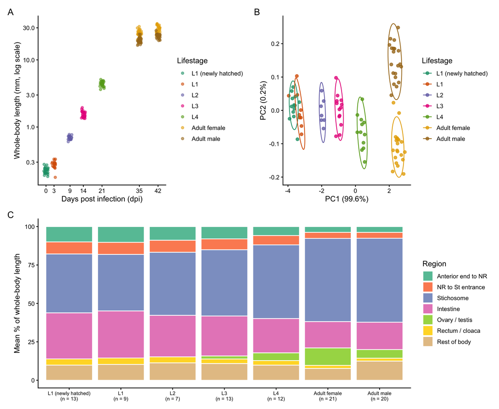

```r
# the composition bars get the full width, so their two-line labels have room
figure1 <- (p_growth | p_pca) / p_comp +
  plot_annotation(tag_levels = "A")

figure1
```

**Check your figure: click to see what it should look like**

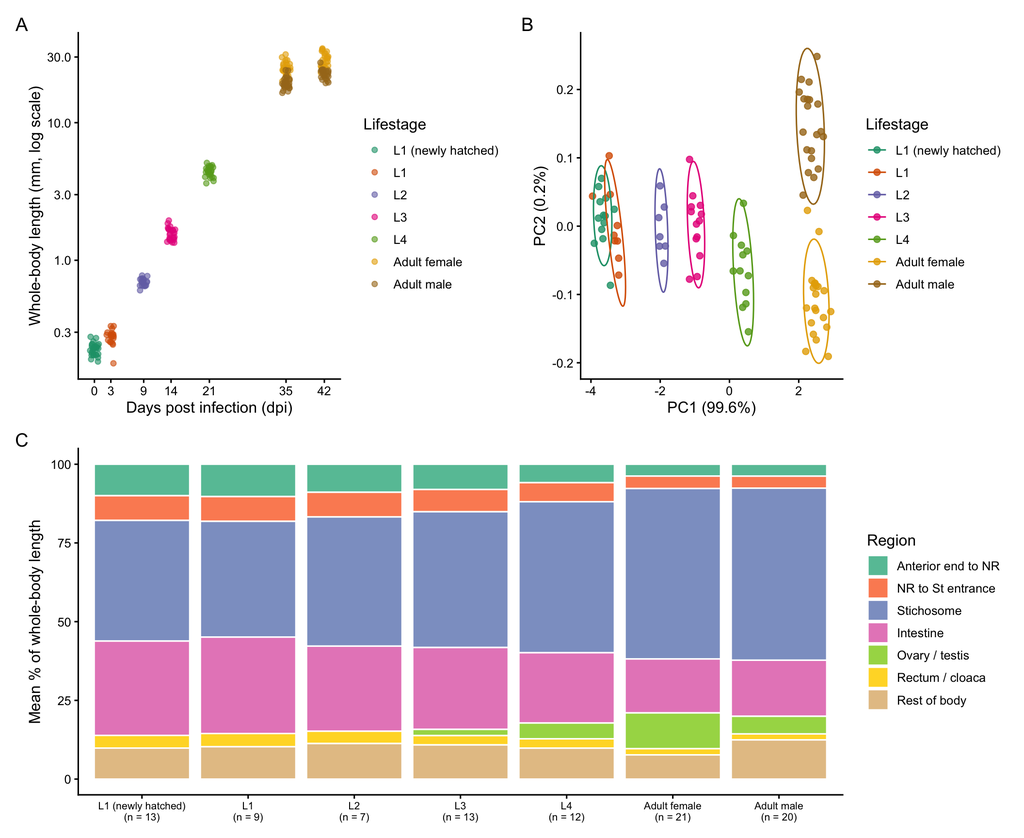

Expected result. The same image is in the project folder as `expected_figures/fig-combined.png`.

Save at manuscript quality:

```r
dir.create("figures", showWarnings = FALSE)
ggsave("figures/figure1.png", figure1, width = 11, height = 9, dpi = 300)
ggsave("figures/figure1.pdf", figure1, width = 11, height = 9)
```

## 16. Practice exercises

Try each exercise yourself first. Open the green **Hint** box only if you are stuck. Write your answers in new chunks: put the cursor on an empty line and press `Ctrl + Alt + I` (`Cmd + Option + I` on a Mac) to insert one.

**1. Fill in the template.** Enter 10 to 15 of your own worms in `trichuris_morphometrics_data_template.xlsx`, export the `data` sheet as CSV (UTF-8), and read it in Section 3.4. Which drop-down or number check caught a mistake as you typed?

**Hint**

In Excel: *File > Save As*, then choose **CSV UTF-8 (Comma delimited)**. Save the file in the `data` folder, then read it with `read_csv("data/your_file.csv")`. Run `glimpse()` on the result: every measurement column should say `<dbl>` (a number). A `<chr>` (text) there means a cell in that column contains text.

**2. Break the data on purpose.** Make a copy of the messy CSV (for example `data/my_messy_copy.csv`) and work on the copy. Change one label to “Adult - female” (a hyphen instead of the en dash). Then change one length in the `WB Length` column to “250 um” (units in the cell). Read the copy in Section 3.1 instead of the original, and rerun 3.1 and 3.2. What changes?

**Hint**

- **The hyphen.** The `count(Lifestage)` table in Section 3.2 now has **9 rows instead of 8**: “Adult - female” shows up as its own group of 1, and “Adult – Female” drops to 54. To R they are different labels. Without the count table you would never notice.
- **“250 um”.** In `glimpse()`, `WB Length` is now `<chr>` (text) instead of `<dbl>`: `read_csv()` reads the **whole column as text**, not just that one cell. Any arithmetic on it, such as `` messy$`WB Length` / 1000 ``, stops with `non-numeric argument to binary operator`.

**3. Mouse effect on composition.** Model `st_pct` with a mouse random effect: `lmer(st_pct ~ lifestage + (1 | host_id), data = filter(worms, !is.na(host_id)))`. What is the ICC? Does the stichosome share vary more between mice than the length does?

**Hint**

Store the model, then reuse the ICC code from Section 13.4:

```r
fit_st_pct <- lmer(st_pct ~ lifestage + (1 | host_id), data = filter(worms, !is.na(host_id)))
VarCorr(fit_st_pct) |>
  as_tibble() |>
  summarise(icc = round(vcov[grp == "host_id"] / sum(vcov), 2))
```

You should get an ICC of about **0.47**, compared with **0.43** for adult length in Section 13.4. So the stichosome share is at least as strongly clustered by mouse as length is.

**4. PC scores.** Model shape PC1 (Section 10.1) against lifestage with a mouse random effect. Which stage differences remain clear once mouse is accounted for?

**Hint**

```r
fit_pc1 <- lmer(PC1 ~ lifestage + (1 | host_id), data = filter(shape_scores, !is.na(host_id)))
emmeans(fit_pc1, pairwise ~ lifestage, lmer.df = "satterthwaite")
```

The second half of the output (`$contrasts`) compares every pair of lifestages, with p-values adjusted for making many comparisons.

**5. Within-stage allometry.** Repeat the stichosome scaling slope (Section 13.7) for adults only. Does it differ from the pooled slope?

**Hint**

Filter `seg_long` to adults before fitting:

```r
st_adults <- seg_long |> filter(segment == "Stichosome", !is.na(host_id), stage == "Adult")
fit_st_adults <- lmer(log10(length_um) ~ log10(wb_length) + (1 | host_id), data = st_adults)
slope_row(fit_st_adults, "lmer, adults only")
```

You should get a slope of about **0.98** (95% CI about 0.88 to 1.08), from 41 worms. That is close to isometry (1), and lower than the pooled 1.08. Within adults the stichosome keeps its share: the pooled slope mostly reflects the change *between* stages.

**6. (Advanced, optional) Power and mice.** This one needs you to edit a long chunk of code. Edit the R simulation chunk in Appendix C (set `eval = TRUE` in the chunk header, or just run it with its ▶ button) to use 8 mice per timepoint instead of 4 or 5, with the same number of worms in total. The chunk writes your simulated worms twice: as a messy sheet and in the tidy layout. Point Section 3.4 at `data/my_simulation_tidy.csv` instead of the provided tidy file. Rerun Section 13.6: how do the mixed-model intervals change? Then try 3 mice with twice as many worms each. (Your numbers will differ from the provided files, because the random numbers differ.)

**Hint**

The number of mice per timepoint is set in one line of the simulation chunk, the one starting `n_mice = c(4, 4,`. Change the six numbers to `8, 8, 8, 8, 8, 8`. In Section 3.4, change the file name to `data/my_simulation_tidy.csv`. Expect the red (mixed-model) intervals in Section 13.6 to get narrower with more mice, even though the number of worms is unchanged.

**7. How much does the final size depend on the last timepoint?** Refit the growth curve from Section 14.3 without the 42 dpi worms. How does the estimated final length of females change?

**Hint**

Filter the data, then reuse the model code with the new data:

```r
gc_no42 <- filter(gc_data, dpi < 42)

fit_gc_no42 <- nlme::nlme(log(wb_length) ~ growth_curve(dpi, lo, hi + male_diff * male, xmid, scal) + mouse,
                          data   = gc_no42,
                          fixed  = lo + hi + xmid + scal + male_diff ~ 1,
                          random = mouse ~ 1 | host_id,
                          start  = coef(fit_gc_nls))

exp(nlme::intervals(fit_gc_no42, which = "fixed")$fixed["hi", ]) / 1000   # final length (mm)
```

Without the 42 dpi worms, the estimated female final length jumps to about **236 mm** (95% CI 44 to 1,260 mm), against 45 mm with them. Up to 35 dpi the data show hardly any slowing down, so the curve has almost nothing to tell it where the plateau is, and the estimate becomes meaningless. A growth curve’s final size is only as good as your latest timepoints: if final size matters, keep sampling until growth has clearly stopped.

**8. A log-ratio for one pair of regions.** In Section 7.2, every centred log-ratio shifts a little when some regions change a lot between the sexes. When the question is about one pair of regions, a simple log-ratio avoids that. Is the intestine longer relative to the stichosome in males than in females? Model `log(intestine / st)` against `sex` in adults.

**Hint**

```r
adults_ratio <- worms |> filter(stage == "Adult", !is.na(st), !is.na(intestine))
fit_ratio <- lm(log(intestine / st) ~ sex, data = adults_ratio)
exp(cbind(estimate = coef(fit_ratio), confint(fit_ratio)))["sexMale", ]
```

You should get about **1.03** (95% CI 0.94 to 1.13, p = 0.51), from 41 worms: relative to the stichosome, the male intestine is about 3% longer, and the interval includes no difference.

The simulation built in a true difference of about 6% (intestine 19% against 18% of the body, stichosome 52% in both, Appendix C). That is too small to detect reliably with 41 worms, especially as stichosome length also varies between mice, which makes it a noisy reference. The 8% difference from the centred log-ratio in Section 7.2 was partly this real difference and partly the shift in the worm’s average region. Every log-ratio answers the question “relative to what?”, so choose the one that matches your question.

**9. Your data.** Put your data in the template layout (Appendix B), point Section 3.4 at your CSV, and run Sections 3.4 to 15. Before that, try the checks from Section 3.1 to 3.3 on your original sheet: what problems do they turn up?

## 17. Where to go next

- **Random slopes.** If the effect of sex or timepoint differs between mice, use `(1 + sex | host_id)` (needs enough worms per mouse and enough mice).
- **More levels of grouping.** If mice come from several experiments, cages or batches, nest the random effects: `(1 | experiment/host_id)`, or `(1 | experiment) + (1 | host_id)` if mice appear in only one experiment.
- **Worms with no host.** For in vitro hatched larvae, a `batch` column (hatching date or egg batch) can play the role of `host_id`, so they can be included in the mixed models.
- **Mice sampled repeatedly.** If a mouse contributes worms at more than one timepoint, the dpi comparison becomes within-mouse, which changes the model and the power. Check Section 12.2 on your real data.
- **Other growth curves.** Section 14 used a logistic curve. Gompertz and von Bertalanffy curves have different shapes and are worth comparing (`AIC()` helps choose between models fitted to the same data). A smooth curve with no fixed shape (`mgcv::gam`, with `s(host_id, bs = "re")` for mouse) is a useful check.
- **More compositional methods.** The `compositions` package has isometric log-ratios (for models with several regions at once) and ways to handle regions that are zero or missing, such as the ovary/testis in young larvae.
- **Very few mice.** Bayesian models (`brms`) handle small numbers of mice more transparently than classical mixed models.
- **True geometric morphometrics.** If you digitise landmark coordinates from images, the `geomorph` package (Procrustes superimposition, then PCA on shape) is the standard route.
- **Classifying groups.** If you want to ask how well measurements discriminate lifestages or species, look at `MASS::lda()` or the `MorphoTools2` package.

## Appendix A: R in ten minutes

You only need a few ideas to follow the code. Run each chunk below, in order, and look at what it prints. These chunks don’t need anything from the main tutorial, so you can run them before Section 0. (Lines starting with `#` are **comments**: notes for humans, which R ignores.)

**Objects and `<-`.** `<-` stores a value under a name, so you can use it later. Read it as “gets”.

```r
n_worms <- 230        # n_worms "gets" 230
n_worms * 2           # use it: R prints the answer below the chunk
```

```
## [1] 460
```

**Vectors with `c()`.** `c()` combines several values into one **vector**. Most R operations work on every element at once.

```r
lengths_um <- c(218.2, 205.5, 235.5)
lengths_um / 1000          # every value converted to mm
```

```
## [1] 0.2182 0.2055 0.2355
```

```r
mean(lengths_um)           # mean() is a function; lengths_um is its argument
```

```
## [1] 219.7333
```

**Functions and arguments.** A function does a job: `mean(x)`, `round(x, digits = 1)`. The values inside the brackets are its **arguments**. Named arguments like `digits = 1` change how it behaves. For help on any function, run `?round` in the Console.

**Missing values: `NA`.** R writes a blank cell as `NA` (“not available”). Most calculations give `NA` if any value is missing, unless you say to skip them with `na.rm = TRUE`.

```r
x <- c(10, NA, 30)
mean(x)                    # NA: R won't guess the missing value
```

```
## [1] NA
```

```r
mean(x, na.rm = TRUE)      # 20: ignore the missing value
```

```
## [1] 20
```

```r
is.na(x)                   # TRUE where a value is missing
```

```
## [1] FALSE  TRUE FALSE
```

**Data frames (tibbles).** A spreadsheet-like table is a **data frame**. The tidyverse version is called a **tibble**. Each column is a vector. `toy$length` or `toy |> pull(length)` picks one column out. You will see both styles.

```r
library(tidyverse)
toy <- tibble(sample = c("S1", "S2", "S3"),
              stage  = c("L1", "L1", "Adult"),
              length = c(220, 240, 25000))
toy
```

| sample | stage | length |
| --- | --- | --- |
| S1 | L1 | 220 |
| S2 | L1 | 240 |
| S3 | Adult | 25000 |

```r
toy$length               # base R way to pick one column
```

```
## [1]   220   240 25000
```

```r
toy |> pull(length)      # tidyverse way: the same values
```

```
## [1]   220   240 25000
```

**Factors.** A **factor** is a categorical variable with a fixed set of **levels** in a set order. Plots and models use that order, so we set it ourselves rather than accept the alphabetical one.

```r
factor(c("L2", "Adult", "L1"), levels = c("L1", "L2", "Adult"))
```

```
## [1] L2    Adult L1
## Levels: L1 L2 Adult
```

**The pipe `|>`.** Read `|>` as “**and then**”. It passes the result on the left into the function on the right, so a long job reads top to bottom:

```r
toy |>
  filter(stage == "L1") |>          # keep L1 rows  (== means "is equal to")
  summarise(mean_length = mean(length))
```

| mean_length |
| --- |
| 230 |

You will often see **`%>%`** in other tutorials, online answers and older scripts. It is the tidyverse’s original pipe, and for everything in this tutorial it does the same job as `|>`. `toy %>% filter(stage == "L1")` and `toy |> filter(stage == "L1")` give the same result. This tutorial uses `|>` because it is built into R (version 4.1 or newer) and is what the tidyverse now recommends.

**Small functions written in place: `\(x)`.** You will often see code such as `\(x) x / 1000`. This is a short **function without a name**: “take a value, call it `x`, and return `x / 1000`”. It is used with helpers like `across()`, which apply the same job to several columns:

```r
convert_to_mm <- \(x) x / 1000     # a function stored under a name...
convert_to_mm(25000)
```

```
## [1] 25
```

```r
toy |> mutate(across(c(length), \(x) x / 1000))   # ...or used in place, unnamed
```

| sample | stage | length |
| --- | --- | --- |
| S1 | L1 | 0.22 |
| S2 | L1 | 0.24 |
| S3 | Adult | 25.00 |

**Packages.** Extra tools come in **packages**. `install.packages("name")` downloads one **once per computer**. `library(name)` switches it on **in every new session**.

## Appendix B: how to set out your own data table

Read this before you collect or enter your own measurements. The most important step happens **before you open R**: how the spreadsheet is laid out. A well-laid-out table makes the analysis easy, and a badly laid-out one means hours of cleaning. The rule is **tidy data**:

> **One row per worm. One column per variable. One value per cell.**

### Two starting points

1. **You are about to enter new data.** Use the template workbook that comes with this tutorial, `trichuris_morphometrics_data_template.xlsx`. It has a `data` sheet with the columns below, drop-down lists for `lifestage`, `sex` and `source`, number checks on the measurement columns, a `data_dictionary` sheet, an `example` sheet of six worms, and a `README` sheet. Export the `data` sheet as CSV (UTF-8) and go to Section 3.4.
2. **You already have a spreadsheet.** Rebuild it once in the template layout (the tips at the end of this appendix help), rather than writing code to convert it. Section 3 shows the kinds of problem to look for in the original.

### Recommended columns

Dark-blue headers in the template are the core columns, and lighter ones are optional.

| Column | What goes in it | Example |
| --- | --- | --- |
| `sample` | Unique ID, one per worm | S001 |
| `host_id` | The mouse the worm came from (blank if it did not come from a host) | M07 |
| `batch` | Optional: experiment, infection cohort, hatching batch or cage | EXP2 |
| `dpi` | Days post infection (a number only) | 21 |
| `lifestage` | L1, L2, L3, L4 or Adult | Adult |
| `sex` | Female, Male, or blank if not sexed | Female |
| `source` | Where the worm came from: `host` or `hatched in vitro` | host |
| `wb_length_um`, `ant_nr_um`, `nr_st_um`, `st_um`, … | One column per raw measurement, in µm, **numbers only** | 24980 |
| `st_number` | Approximate stichosome number | 55 |
| `observer`, `measured_on` | Optional: who measured it and when (useful for checking measurement drift) | AB, 2026-03-14 |
| `notes` | Free text for anything unusual | tail broken |

Note that **stage and sex are separate columns**. Putting both in one cell (for example “Adult – Female”) forces you to split them apart before every analysis, and it makes it impossible to ask a question such as “does sex matter across all adult timepoints?” without cleaning first.

### How to spot a column that needs splitting

Look for these signs in a column:

- **A separator inside the values**: a dash, slash, semicolon, comma or brackets (“Adult – Female”, “St (or end of Os)”).
- **A qualifier tacked on**: “L1 – newly hatched” adds a note about origin to a stage.
- **A value plus a unit**: “250 µm” in a cell.
- **A range or approximation**: “40–45” or “~40” in a count cell.
- **A compound ID** that packs two things together, for example “M07-S12” for host and worm.
- **A question you can’t answer with a simple filter**: if “all adults, regardless of sex” needs text matching, the column holds two variables.

**Split a column when each part is something you might filter, group or plot by on its own.** Don’t split an ID such as “S001” that you would never analyse in pieces.

Three questions to ask about every column:

1. **Does it hold one variable only?** “Adult – Female” holds two (stage and sex). “L1 – newly hatched” holds two (stage and where the worm came from).
2. **Is every value spelled the same way?** “L1”, “l1”, “L1” (trailing space) and “Larva 1” are four different categories to R. Use drop-down lists.
3. **Could it be calculated from other columns?** If so, don’t type it. Percentages of total length can be computed in R from the lengths, so they never disagree with the lengths.

### Avoid and instead

| Avoid | Instead |
| --- | --- |
| “Adult – Female” (stage and sex in one cell) | `lifestage` = “Adult”, `sex` = “Female” |
| “L1 – newly hatched” mixed in with “L1” in the same column | `lifestage` = “L1” for both, and record the difference in `source` (or with `dpi` = 0) |
| Typing the same category differently (“L1”, “l1”, “L1”, “Larva 1”) | One spelling, always. Use a drop-down list in your spreadsheet to enforce it |
| Long headers with spaces, line breaks and symbols (“% of Total – NR to Entrance of St (or end of Os)”) | Short plain headers with units: `nr_st_um`. Put the full description in the data dictionary |
| Units inside cells (“250 µm”) | Units in the header only. A cell with “250 µm” is read as text, not a number |
| Zero for “not measured”, or “-”, “n/a”, “?” | Leave the cell blank. Use 0 only when the measurement really was zero |
| Percent-of-total columns calculated in the spreadsheet | Record raw lengths only and let R calculate percentages. This avoids copy/paste and arithmetic errors |
| Merged cells, blank rows, blank columns, totals or averages under the data | One header row, then data only, with no gaps |
| Colours or bold text carrying information (for example red = damaged) | A real column such as `notes` or `damaged` (yes/no). Colours are lost when you export |
| Dates as “3/4/26” (ambiguous) | ISO format: 2026-04-03 |
| Recording a sum and all its parts without checking they agree | If you record `ant_nr_um`, `nr_st_um` **and** `ant_st_um`, check that the first two add up to the third (Section 5.2) |

### Suggested splits for a typical lab sheet (like the practice file)

[output not shown]

### When to combine instead

The opposite problem is **one variable spread across several columns**, for example separate “Female length” and “Male length” columns, or one column per timepoint. Those should be a single `length` column plus `sex` or `dpi`.

The design used here (one row per worm, one column per landmark) is already the right shape. Move to **one row per measurement** only if the same worm is measured more than once, for example by several observers. In that case add `observer` and `replicate` columns.

### The data dictionary

A data dictionary is a table that says what every column means. It is the most useful thing you can give a collaborator (or yourself in a year). The template contains a full one. Here is the shape of it:

| column | meaning | type | unit | allowed values |
| --- | --- | --- | --- | --- |
| `sample` | Unique ID for each worm | text |  | never repeated |
| `dpi` | Days post infection (0 = hatched in vitro) | whole number | days | 0 or more |
| `lifestage` | Developmental stage | list |  | L1, L2, L3, L4, Adult |
| `sex` | Sex; blank if not sexed | list |  | Female, Male |
| `wb_length_um` | Whole-body length | number | µm | 0 or more |

It should also say what a **blank** means. For example: “blank in `ov_ts_um` means the organ was not yet present (early larvae) or not measured. It does *not* mean zero.”

### General habits for tidy data

**Column names**

- Short, lowercase, with underscores and no spaces or symbols.
- Put the unit in the name (`wb_length_um`) and keep a consistent order (`ant_nr` before `nr_st`).
- Never start a name with a digit.

**Categories**

- One fixed spelling for each category, enforced with a drop-down list.
- Watch for trailing spaces, capitalisation differences and en dashes versus hyphens. Each creates a new group in R.
- Put explanations in a `notes` column, never inside the category.

**Missing values**

- Leave cells blank. Don’t use 0, “-”, “n/a” or “?”.
- A blank can mean “not measured” or “not applicable” (an ovary in an early larva). Say what it means in the data dictionary. If R needs to tell the two apart, add a column that records it.

**IDs and structure**

- Keep IDs unique and spelled identically every time (“M07”, never “M7”).
- Record every grouping factor that might make worms resemble each other: host, batch, observer, measurement date.

**Sheet hygiene**

- One table per sheet and one header row.
- No merged cells, blank rows, subtotals, or colour used as data.
- ISO dates (2026-04-03).

**Raw versus calculated**

- Record only what you measured. Percentages, totals and differences can be calculated.
- If you do record a sum and all its parts, check they agree (Section 5.2).

**Documentation and checks**

- Write a data dictionary: meaning, unit, allowed values, and what a blank means.
- Keep the raw file untouched.
- Run the same checks every time you add data: unique IDs, plausible ranges, parts that add up, and a count of rows per group.

### Making the rebuild easier

- Start from the template workbook so the headers, drop-downs and dictionary are already set up.
- Paste measurement columns in as **values only**, so spreadsheet formatting doesn’t come along.
- Excel and Google Sheets can split “Adult – Female” with *Text to Columns*, using the delimiter ” – ” (a space, an en dash, a space). Then fill `source` with a filter.
- Enter new data straight into the tidy layout, so you won’t need to convert it again.

## Appendix C: how the practice data were simulated

The practice files were made by `tools/make_simulated_data.py`. The R chunk below is the **same design written in R**: how many worms per timepoint, their average size and body proportions, the mouse effects, and the deliberate untidiness (spreadsheet headers, stray spaces, transcription errors and empty rows). Reading it shows exactly what structure the analyses are meant to recover, for example that mice differ in worm size, which is why the mixed models in Section 13 are needed.

It is **not run** when you knit (`eval = FALSE`), and you only need to run it for Exercise 6. If you do run it, it writes `data/my_simulation_messy.csv` and the same worms in the tidy layout, `data/my_simulation_tidy.csv`. Its random numbers differ from the provided files, so don’t mix the two.

```r
set.seed(2026)

# Design: how many worms per timepoint / lifestage, and their average size (µm)
design <- tribble(
  ~dpi, ~lifestage,            ~mean_length_um, ~n,
  0,    "L1 (newly hatched)",        220,        30,
  3,    "L1",                        280,        20,
  9,    "L2",                        700,        20,
  14,   "L3",                       1500,        25,
  21,   "L4",                       4500,        25,
  35,   "Adult female",            25000,        30,
  35,   "Adult male",              20000,        30,
  42,   "Adult female",            28000,        25,
  42,   "Adult male",              22000,        25
)

# Average proportion of the body in each region, by lifestage (each row sums to 1)
prop_means <- tribble(
  ~lifestage,            ~p_ant_nr, ~p_nr_st, ~p_st, ~p_int, ~p_ov_ts, ~p_rt_cl, ~p_rest,
  "L1 (newly hatched)",    0.10,      0.08,    0.38,   0.30,   0.00,     0.04,     0.10,
  "L1",                    0.10,      0.08,    0.38,   0.30,   0.00,     0.04,     0.10,
  "L2",                    0.09,      0.08,    0.40,   0.28,   0.00,     0.04,     0.11,
  "L3",                    0.08,      0.07,    0.44,   0.25,   0.02,     0.03,     0.11,
  "L4",                    0.06,      0.06,    0.48,   0.22,   0.05,     0.03,     0.10,
  "Adult female",          0.04,      0.04,    0.52,   0.18,   0.12,     0.02,     0.08,
  "Adult male",            0.04,      0.04,    0.52,   0.19,   0.06,     0.02,     0.13
)

# Mice: each mouse is culled at ONE timepoint, so mice are nested within dpi.
# Each mouse gets its own random shift in worm size and in relative stichosome length.
mice <- tibble(dpi    = c(3, 9, 14, 21, 35, 42),
               n_mice = c(4, 4,  5,  5,  5,  5)) |>
  uncount(n_mice) |>
  mutate(
    host_id         = sprintf("M%02d", row_number()),
    mouse_size      = rnorm(n(), 0, 0.08),
    mouse_st_effect = rnorm(n(), 0, 0.06)
  )

# The mice available at each timepoint (none at dpi 0: those larvae were hatched in vitro)
host_pool <- mice |>
  group_by(dpi) |>
  summarise(hosts = list(host_id), .groups = "drop")

sim <- design |>
  left_join(prop_means, by = "lifestage") |>
  uncount(n) |>                                    # one row per worm
  left_join(host_pool, by = "dpi") |>
  mutate(host_id = map_chr(hosts, \(h) if (is.null(h)) NA_character_ else base::sample(h, 1))) |>
  select(-hosts) |>
  left_join(select(mice, host_id, mouse_size, mouse_st_effect), by = "host_id") |>
  mutate(
    sample = sprintf("S%03d", row_number()),

    # worms with no host get no mouse effect
    across(c(mouse_size, mouse_st_effect), \(x) replace_na(x, 0)),

    # worm size: lifestage average x mouse effect x individual variation
    wb_length = mean_length_um * exp(mouse_size + rnorm(n(), 0, 0.08)),

    # relative stichosome length also varies by mouse
    p_st = p_st * exp(mouse_st_effect),

    # add individual variation to each proportion, then rescale to sum to 1
    across(starts_with("p_"), \(p) p * exp(rnorm(length(p), 0, 0.08))),
    total_p = p_ant_nr + p_nr_st + p_st + p_int + p_ov_ts + p_rt_cl + p_rest,
    across(starts_with("p_"), \(p) p / total_p),

    # absolute lengths (µm)
    ant_nr    = p_ant_nr * wb_length,
    nr_st     = p_nr_st  * wb_length,
    ant_st    = ant_nr + nr_st,
    st        = p_st     * wb_length,
    intestine = p_int    * wb_length,
    ov_ts     = p_ov_ts  * wb_length,
    rt_cl     = p_rt_cl  * wb_length,
    rest      = p_rest   * wb_length,

    # percentages of whole-body length
    ant_nr_pct    = p_ant_nr * 100,
    nr_st_pct     = p_nr_st  * 100,
    ant_st_pct    = ant_st / wb_length * 100,
    st_pct        = p_st     * 100,
    intestine_pct = p_int    * 100,
    ov_ts_pct     = p_ov_ts  * 100,
    rt_cl_pct     = p_rt_cl  * 100,
    rest_pct      = p_rest   * 100,

    # approximate stichosome number: fixed early in development (about 50 to 60), whatever the body size
    st_number = round(55 + rnorm(n(), 0, 2.5)),

    # which measurements did this worm get? (partial measurement)
    meas_set = base::sample(c("length_only", "head", "full"), n(),
                            replace = TRUE, prob = c(0.35, 0.25, 0.40)),
    st_number = if_else(meas_set == "full" &
                          !lifestage %in% c("L1 (newly hatched)", "L1") &
                          runif(n()) < 0.6,
                        st_number, NA_real_)
  ) |>
  mutate(
    # head landmarks missing if the worm was only measured for length
    across(c(ant_nr, nr_st, ant_st, ant_nr_pct, nr_st_pct, ant_st_pct),
           \(x) if_else(meas_set == "length_only", NA_real_, x)),
    # body regions only present for fully measured worms
    across(c(st, intestine, ov_ts, rt_cl, rest,
             st_pct, intestine_pct, ov_ts_pct, rt_cl_pct, rest_pct),
           \(x) if_else(meas_set != "full", NA_real_, x)),
    # ovary/testis structurally absent in the youngest larvae
    across(c(ov_ts, ov_ts_pct),
           \(x) if_else(lifestage %in% c("L1 (newly hatched)", "L1", "L2"), NA_real_, x)),
    # round like a real spreadsheet
    across(c(wb_length, ant_nr, nr_st, ant_st, st, intestine, ov_ts, rt_cl, rest),
           \(x) round(x, 1)),
    across(ends_with("_pct"), \(x) round(x, 2)),

    # the lifestage label as it appears in the spreadsheet (stage and sex combined)
    lifestage_raw = recode(lifestage,
                           "L1 (newly hatched)" = "L1 \u2013 newly hatched",
                           "Adult female"       = "Adult \u2013 Female",
                           "Adult male"         = "Adult \u2013 Male",
                           .default = lifestage)
  )

# Slip in two transcription errors (ant_st inflated) for the QC step to find
sim <- sim |>
  mutate(ant_st_n = cumsum(!is.na(ant_st)),        # 1, 2, 3 ... counting only worms with ant_st
         ant_st   = if_else(!is.na(ant_st) & ant_st_n %in% c(7, 53), ant_st * 1.6, ant_st)) |>
  select(-ant_st_n)

# Spreadsheet-style headers (what the real file looks like)
raw_headers <- c(
  "Timepoint (dpi)", "Lifestage", "Sample", "Host ID", "WB Length",
  "Anterior body end to NR",
  "% of Total \u2013 Anterior body end to NR",
  "Anterior body end to Entrance of St (or end of Os)",
  "% of Total \u2013 Anterior body end to Entrance of St (or end of Os)",
  "NR to Entrance of St (or end of Os)",
  "% of Total \u2013 NR to Entrance of St (or end of Os)",
  "St", "% of Total \u2013 St",
  "Int", "% of Total \u2013 Int",
  "Ov/Ts", "% of Total \u2013 Ov/Ts",
  "Rt/Cl", "% of Total \u2013 Rt/Cl",
  "Rest of body", "% of Total \u2013 Rest of body",
  "APPROX. St numbers"
)

worms_raw_sim <- sim |>
  select(dpi, lifestage_raw, sample, host_id, wb_length,
         ant_nr, ant_nr_pct, ant_st, ant_st_pct, nr_st, nr_st_pct,
         st, st_pct, intestine, intestine_pct, ov_ts, ov_ts_pct,
         rt_cl, rt_cl_pct, rest, rest_pct, st_number) |>
  set_names(raw_headers)

# Two stray trailing spaces in the lifestage labels (a very common typo)
worms_raw_sim <- worms_raw_sim |>
  mutate(Lifestage = if_else(row_number() %in% c(60, 140), str_c(Lifestage, " "), Lifestage))

# Eight completely empty rows at the bottom, as often left behind in a spreadsheet
worms_raw_sim <- bind_rows(worms_raw_sim, tibble(.rows = 8))

dir.create("data", showWarnings = FALSE)
write_csv(worms_raw_sim, "data/my_simulation_messy.csv", na = "")   # blank cells, like Excel

# The same worms in the tidy template layout, ready for Section 3.4 (Exercise 6)
sim_tidy <- sim |>
  mutate(sex       = case_when(lifestage == "Adult female" ~ "Female",
                               lifestage == "Adult male"   ~ "Male"),
         source    = if_else(lifestage == "L1 (newly hatched)", "hatched in vitro", "host"),
         lifestage = str_remove(lifestage, " .*")) |>     # "Adult female" -> "Adult", "L1 (newly hatched)" -> "L1"
  select(sample, host_id, dpi, lifestage, sex, source,
         wb_length, ant_nr, ant_st, nr_st, st, intestine, ov_ts, rt_cl, rest, st_number) |>
  rename_with(\(x) str_c(x, "_um"), wb_length:rest)
write_csv(sim_tidy, "data/my_simulation_tidy.csv", na = "")
```